# Student Academic Performance

## Introduction

This report presents supervised learning analysis aimed at predicting exam scores using machine learning models. The objective of this study is to evaluate the predictive ability of demographic, academic, and behavioral features in explaining the variation of student exam performance. A range of linear and nonlinear regression models were implemented, including ordinary least squares, regularized linear models (Ridge, Lasso, Elastic Net), support vector regression, tree-based methods, and gradient boosting.

To ensure methodological rigor and prevent data leakage, the dataset was partitioned into training and holdout test sets prior to model development. Model selection and hyperparameter tuning were conducted using 10-fold cross-validation on the training data. All preprocessing steps were implemneted using machine learning pipelines. This methodology, ensures that transformations are learnbed exclusively from the training folds and applied consisstently during validation and final evaluation. Model performance was assessed using root mean squared error (RMSE), Mean absolute error (MAE), and $R^2$, with RMSE used as the primary metric for model comparison.

The analysis aims not only to identify the best-performing predictive model, but also to assess whether exam performance is better explained by linear relationships or by more flexible nonlinear structures. Through systematic comparison and validation, this notebook establishes a statistically grounded framework for modeling and interpreting exam score outcomes.

## Loading the Data

```python
# Core packages
import numpy as np
import pandas as pd

# Statistical Packages
from scipy.stats import norm
import statsmodels.api as sm

# Visualization
import matplotlib.pyplot as plt
import seaborn as sns

# Markdown
from IPython.display import display, Markdown

# Navigation
from pathlib import Path

# Function utils
from typing import Callable, Dict, Optional, Tuple

# Seed generator
SEED_STATE = 444
np.random.seed(SEED_STATE)


# Favorite Colors
fav_colors = ['#BF616AFF',
              '#8fbcbb',
              '#A3BE8CFF',
              '#EBCB8BFF',
              '#B48EADFF',
              '#AF7D32FF',
              '#D08770FF',
              '#F0D8C0',
              '#2e3440']
```

```python
# Utility Functions
###################################################################################################################################################################################
def categorical_table(series: pd.Series) -> pd.DataFrame:
    '''
    Return a compact summary table for a categorical Series:
    counts + proportions + percents
    '''
    if not isinstance(series, pd.Series):
        raise TypeError('Input must be a pandas Series.')

    counts = series.value_counts(dropna = False)
    props  = series.value_counts(normalize = True, dropna = False)

    out = pd.concat([counts, props], axis=1)
    out.columns = ['count', 'proportion']
    out['percent'] = (out['proportion'] * 100).round(2)

    return out

###################################################################################################################################################################################

def distribution_plot(series,
                      var_name : str = 'Variable',
                      transforms : Optional[Dict[str, Callable]] = None,
                      dropna : bool = True,
                      ddof : int = 1,
                      bins : int = 30,
                      figsize : Tuple[int, int] = (10, 8),
                      hist_color = '#BF616AFF',
                      edgecolor : str = 'black',
                      qq_line : str = 's',
                      gridsize : int = 1000,
                      save_path : Optional[Path] = None,
                      dpi : int = 400,
                      bbox_inches : str = 'tight',
                      show : bool = True,
                      close : bool = True) -> None:
    '''
    Create distribution (Histogram + QQ plots) for a pandas Series. Optionally include additional rows created via transformations.

    Parameters
    ----------
    series : pd.Series or array-like - Input values.
    var_name : str - Display name for titles/labels.
    transforms : dict[str, callable] or None - Transformations to be applied to series value. If None, only the raw (untransformed) row is produced.
    dropna : bool - Drop NA values before plotting.
    ddof : int - ddof for standard deviation in Normal distribution.
    bins : int - Histogram bins. Default is 30
    figsize : tuple - Base figure size for a single row.
    hist_color - Histogram fill color.
    edgecolor : str -Histogram edgecolor.
    qq_line : str -Line option passed to statsmodels.qqplot (e.g., 's', 'r', 'q', None).
    gridsize : int - Number of points for the Normal curve x-grid. Default is 10000
    save_path : Path or None- If provided, saves the figure to this path.
    dpi : int - Save DPI. Default is 400
    show : bool -Whether to plt.show().
    close : bool- Whether to plt.close(fig) after showing/saving.

    Returns
    -------
    matplotlib.figure.Figure
    '''
    # Conversion
    x0 = np.asarray(series)

    # Remove missing values
    if dropna:
        x0 = x0[~np.isnan(x0)]

    # Build list of panels including raw and transformations
    transforms = transforms or {}
    panel_specs = [('raw', x0)]

    for label, fn in transforms.items():
        try:
            xt = fn(series)
        except Exception:
            # If function requires array
            xt = fn(x0)

        xt = np.asarray(xt)

        if dropna:
            xt = xt[~np.isnan(xt)]

        panel_specs.append((label, xt))

    nrows = len(panel_specs)

    # Figure dimensions
    fig_w, fig_h = figsize
    fig, axes = plt.subplots(nrows = nrows,
                             ncols = 2,
                             figsize = (fig_w, fig_h))

    # Normalize axes shape for nrows == 1
    if nrows == 1:
        axes = np.array([axes])

    data_dict = {}

    for r, (label, x) in enumerate(panel_specs):

        # Store plotted values
        data_dict[label] = x

        # Skip empty panels
        if x.size == 0:
            axes[r, 0].text(0.5, 0.5, 'No data to plot',
                            ha = 'center', va = 'center', transform = axes[r, 0].transAxes)
            axes[r, 1].text(0.5, 0.5, 'No data to plot',
                            ha = 'center', va = 'center', transform = axes[r, 1].transAxes)
            continue

        ################################################################################################################################################
        # Normal overlay parameters
        ################################################################################################################################################
        mu = x.mean()
        sd = x.std(ddof = ddof)

        x_grid = np.linspace(x.min(), x.max(), gridsize)

        # Guard against sd == 0 (flat distribution)
        if sd > 0:
            y_pdf = norm.pdf(x_grid, loc = mu, scale = sd)
        else:
            y_pdf = np.zeros_like(x_grid)

        ################################################################################################################################################
        # Histogram + Normal overlay
        ################################################################################################################################################
        axes[r, 0].hist(x,
                        bins = bins,
                        density = True,
                        color = hist_color,
                        edgecolor = edgecolor)

        axes[r, 0].plot(x_grid, y_pdf, color = 'black', linewidth = 2)

        if label == 'raw':
            title_left = f'{var_name}'
            xlab = f'{var_name}'
        else:
            title_left = f'{var_name} ({label})'
            xlab = f'{label}({var_name})'

        axes[r, 0].set_title(title_left, loc = 'left')
        axes[r, 0].set_xlabel(xlab)
        axes[r, 0].set_ylabel('Density')

        ################################################################################################################################################
        # Q–Q plot
        ################################################################################################################################################
        sm.qqplot(x, line = qq_line, ax = axes[r, 1])

        qq_title = 'Q–Q plot' if label == 'raw' else f'Q–Q plot ({label})'
        axes[r, 1].set_title(qq_title, loc = 'left')

    plt.tight_layout()

    if save_path is not None:
        plt.savefig(save_path,
                    dpi = dpi,
                    bbox_inches = bbox_inches)

    if show:
        plt.show();

    if close:
        plt.close(fig);
###################################################################################################################################################################################
```

```python
# Directory Paths
## Data
### Raw
RAW_DIR = Path('../data/raw')
PROCESSED_DIR = Path('../data/processed')
MODEL_DIR = Path('../data/models')
## Figures
FIG_DIR = Path('../figures')
```

```python
DATA_PATH = RAW_DIR / 'StudentPerformanceFactors.csv'

if DATA_PATH.exists():
    df = pd.read_csv(filepath_or_buffer = DATA_PATH)
else:
    print(f'Data file not found at {DATA_PATH}')
```

Structural check of dataset:

```python
print(f'The feature dataframe contains {df.shape[0]} rows and {df.shape[1]} columns.')
```

```
The feature dataframe contains 6607 rows and 20 columns.
```

```python
df.head()
```

|  | Hours_Studied | Attendance | Parental_Involvement | Access_to_Resources | Extracurricular_Activities | Sleep_Hours | Previous_Scores | Motivation_Level | Internet_Access | Tutoring_Sessions | Family_Income | Teacher_Quality | School_Type | Peer_Influence | Physical_Activity | Learning_Disabilities | Parental_Education_Level | Distance_from_Home | Gender | Exam_Score |
| --- | --- | --- | --- | --- | --- | --- | --- | --- | --- | --- | --- | --- | --- | --- | --- | --- | --- | --- | --- | --- |
| 0 | 23 | 84 | Low | High | No | 7 | 73 | Low | Yes | 0 | Low | Medium | Public | Positive | 3 | No | High School | Near | Male | 67 |
| 1 | 19 | 64 | Low | Medium | No | 8 | 59 | Low | Yes | 2 | Medium | Medium | Public | Negative | 4 | No | College | Moderate | Female | 61 |
| 2 | 24 | 98 | Medium | Medium | Yes | 7 | 91 | Medium | Yes | 2 | Medium | Medium | Public | Neutral | 4 | No | Postgraduate | Near | Male | 74 |
| 3 | 29 | 89 | Low | Medium | Yes | 8 | 98 | Medium | Yes | 1 | Medium | Medium | Public | Negative | 4 | No | High School | Moderate | Male | 71 |
| 4 | 19 | 92 | Medium | Medium | Yes | 6 | 65 | Medium | Yes | 3 | Medium | High | Public | Neutral | 4 | No | College | Near | Female | 70 |

```python
df.tail()
```

|  | Hours_Studied | Attendance | Parental_Involvement | Access_to_Resources | Extracurricular_Activities | Sleep_Hours | Previous_Scores | Motivation_Level | Internet_Access | Tutoring_Sessions | Family_Income | Teacher_Quality | School_Type | Peer_Influence | Physical_Activity | Learning_Disabilities | Parental_Education_Level | Distance_from_Home | Gender | Exam_Score |
| --- | --- | --- | --- | --- | --- | --- | --- | --- | --- | --- | --- | --- | --- | --- | --- | --- | --- | --- | --- | --- |
| 6602 | 25 | 69 | High | Medium | No | 7 | 76 | Medium | Yes | 1 | High | Medium | Public | Positive | 2 | No | High School | Near | Female | 68 |
| 6603 | 23 | 76 | High | Medium | No | 8 | 81 | Medium | Yes | 3 | Low | High | Public | Positive | 2 | No | High School | Near | Female | 69 |
| 6604 | 20 | 90 | Medium | Low | Yes | 6 | 65 | Low | Yes | 3 | Low | Medium | Public | Negative | 2 | No | Postgraduate | Near | Female | 68 |
| 6605 | 10 | 86 | High | High | Yes | 6 | 91 | High | Yes | 2 | Low | Medium | Private | Positive | 3 | No | High School | Far | Female | 68 |
| 6606 | 15 | 67 | Medium | Low | Yes | 9 | 94 | Medium | Yes | 0 | Medium | Medium | Public | Positive | 4 | No | Postgraduate | Near | Male | 64 |

```python
df.info()
```

```
<class 'pandas.DataFrame'>
RangeIndex: 6607 entries, 0 to 6606
Data columns (total 20 columns):
 #   Column                      Non-Null Count  Dtype
---  ------                      --------------  -----
 0   Hours_Studied               6607 non-null   int64
 1   Attendance                  6607 non-null   int64
 2   Parental_Involvement        6607 non-null   str
 3   Access_to_Resources         6607 non-null   str
 4   Extracurricular_Activities  6607 non-null   str
 5   Sleep_Hours                 6607 non-null   int64
 6   Previous_Scores             6607 non-null   int64
 7   Motivation_Level            6607 non-null   str
 8   Internet_Access             6607 non-null   str
 9   Tutoring_Sessions           6607 non-null   int64
 10  Family_Income               6607 non-null   str
 11  Teacher_Quality             6529 non-null   str
 12  School_Type                 6607 non-null   str
 13  Peer_Influence              6607 non-null   str
 14  Physical_Activity           6607 non-null   int64
 15  Learning_Disabilities       6607 non-null   str
 16  Parental_Education_Level    6517 non-null   str
 17  Distance_from_Home          6540 non-null   str
 18  Gender                      6607 non-null   str
 19  Exam_Score                  6607 non-null   int64
dtypes: int64(7), str(13)
memory usage: 1.0 MB
```

Missingness Check:

```python
df.isnull().sum()
```

```
Hours_Studied                  0
Attendance                     0
Parental_Involvement           0
Access_to_Resources            0
Extracurricular_Activities     0
Sleep_Hours                    0
Previous_Scores                0
Motivation_Level               0
Internet_Access                0
Tutoring_Sessions              0
Family_Income                  0
Teacher_Quality               78
School_Type                    0
Peer_Influence                 0
Physical_Activity              0
Learning_Disabilities          0
Parental_Education_Level      90
Distance_from_Home            67
Gender                         0
Exam_Score                     0
dtype: int64
```

There are three variables with missing values: `Teach_Quality`, `Parent_Education_Level`, and `Distance_from_Home`. All of these variables make up a low amount of missing data (<2%). Simple imputation methods will be used to deal with these missing values.

Duplication check:

```python
df[df.duplicated(keep = False)]
```

|  | Hours_Studied | Attendance | Parental_Involvement | Access_to_Resources | Extracurricular_Activities | Sleep_Hours | Previous_Scores | Motivation_Level | Internet_Access | Tutoring_Sessions | Family_Income | Teacher_Quality | School_Type | Peer_Influence | Physical_Activity | Learning_Disabilities | Parental_Education_Level | Distance_from_Home | Gender | Exam_Score |
| --- | --- | --- | --- | --- | --- | --- | --- | --- | --- | --- | --- | --- | --- | --- | --- | --- | --- | --- | --- | --- |

There are no duplicated values within the dataset.

## Data overview

### Variable Summary

#### Numerical Summary

```python
df.describe(include = [np.int64])
```

|  | Hours_Studied | Attendance | Sleep_Hours | Previous_Scores | Tutoring_Sessions | Physical_Activity | Exam_Score |
| --- | --- | --- | --- | --- | --- | --- | --- |
| count | 6607.000000 | 6607.000000 | 6607.00000 | 6607.000000 | 6607.000000 | 6607.000000 | 6607.000000 |
| mean | 19.975329 | 79.977448 | 7.02906 | 75.070531 | 1.493719 | 2.967610 | 67.235659 |
| std | 5.990594 | 11.547475 | 1.46812 | 14.399784 | 1.230570 | 1.031231 | 3.890456 |
| min | 1.000000 | 60.000000 | 4.00000 | 50.000000 | 0.000000 | 0.000000 | 55.000000 |
| 25% | 16.000000 | 70.000000 | 6.00000 | 63.000000 | 1.000000 | 2.000000 | 65.000000 |
| 50% | 20.000000 | 80.000000 | 7.00000 | 75.000000 | 1.000000 | 3.000000 | 67.000000 |
| 75% | 24.000000 | 90.000000 | 8.00000 | 88.000000 | 2.000000 | 4.000000 | 69.000000 |
| max | 44.000000 | 100.000000 | 10.00000 | 100.000000 | 8.000000 | 6.000000 | 101.000000 |

#### Categorical Summary

```python
df.describe(include = ['str'])
```

|  | Parental_Involvement | Access_to_Resources | Extracurricular_Activities | Motivation_Level | Internet_Access | Family_Income | Teacher_Quality | School_Type | Peer_Influence | Learning_Disabilities | Parental_Education_Level | Distance_from_Home | Gender |
| --- | --- | --- | --- | --- | --- | --- | --- | --- | --- | --- | --- | --- | --- |
| count | 6607 | 6607 | 6607 | 6607 | 6607 | 6607 | 6529 | 6607 | 6607 | 6607 | 6517 | 6540 | 6607 |
| unique | 3 | 3 | 2 | 3 | 2 | 3 | 3 | 2 | 3 | 2 | 3 | 3 | 2 |
| top | Medium | Medium | Yes | Medium | Yes | Low | Medium | Public | Positive | No | High School | Near | Male |
| freq | 3362 | 3319 | 3938 | 3351 | 6108 | 2672 | 3925 | 4598 | 2638 | 5912 | 3223 | 3884 | 3814 |

```python
cols = df.select_dtypes(include = ['str']).columns

for col in cols:
    display(Markdown(f'### `{col}`'))
    display(categorical_table(df[col]))
    display(Markdown('---'))
```

`Parental_Involvement`

| Parental_Involvement | count | proportion | percent |
| --- | --- | --- | --- |
| Medium | 3362 | 0.508854 | 50.89 |
| High | 1908 | 0.288785 | 28.88 |
| Low | 1337 | 0.202361 | 20.24 |

`Access_to_Resources`

| Access_to_Resources | count | proportion | percent |
| --- | --- | --- | --- |
| Medium | 3319 | 0.502346 | 50.23 |
| High | 1975 | 0.298925 | 29.89 |
| Low | 1313 | 0.198729 | 19.87 |

`Extracurricular_Activities`

| Extracurricular_Activities | count | proportion | percent |
| --- | --- | --- | --- |
| Yes | 3938 | 0.596035 | 59.6 |
| No | 2669 | 0.403965 | 40.4 |

`Motivation_Level`

| Motivation_Level | count | proportion | percent |
| --- | --- | --- | --- |
| Medium | 3351 | 0.507189 | 50.72 |
| Low | 1937 | 0.293174 | 29.32 |
| High | 1319 | 0.199637 | 19.96 |

`Internet_Access`

| Internet_Access | count | proportion | percent |
| --- | --- | --- | --- |
| Yes | 6108 | 0.924474 | 92.45 |
| No | 499 | 0.075526 | 7.55 |

`Family_Income`

| Family_Income | count | proportion | percent |
| --- | --- | --- | --- |
| Low | 2672 | 0.404420 | 40.44 |
| Medium | 2666 | 0.403511 | 40.35 |
| High | 1269 | 0.192069 | 19.21 |

`Teacher_Quality`

| Teacher_Quality | count | proportion | percent |
| --- | --- | --- | --- |
| Medium | 3925 | 0.594067 | 59.41 |
| High | 1947 | 0.294687 | 29.47 |
| Low | 657 | 0.099440 | 9.94 |
| NaN | 78 | 0.011806 | 1.18 |

`School_Type`

| School_Type | count | proportion | percent |
| --- | --- | --- | --- |
| Public | 4598 | 0.695929 | 69.59 |
| Private | 2009 | 0.304071 | 30.41 |

`Peer_Influence`

| Peer_Influence | count | proportion | percent |
| --- | --- | --- | --- |
| Positive | 2638 | 0.399273 | 39.93 |
| Neutral | 2592 | 0.392311 | 39.23 |
| Negative | 1377 | 0.208415 | 20.84 |

`Learning_Disabilities`

| Learning_Disabilities | count | proportion | percent |
| --- | --- | --- | --- |
| No | 5912 | 0.894809 | 89.48 |
| Yes | 695 | 0.105191 | 10.52 |

`Parental_Education_Level`

| Parental_Education_Level | count | proportion | percent |
| --- | --- | --- | --- |
| High School | 3223 | 0.487816 | 48.78 |
| College | 1989 | 0.301044 | 30.10 |
| Postgraduate | 1305 | 0.197518 | 19.75 |
| NaN | 90 | 0.013622 | 1.36 |

`Distance_from_Home`

| Distance_from_Home | count | proportion | percent |
| --- | --- | --- | --- |
| Near | 3884 | 0.587861 | 58.79 |
| Moderate | 1998 | 0.302407 | 30.24 |
| Far | 658 | 0.099591 | 9.96 |
| NaN | 67 | 0.010141 | 1.01 |

`Gender`

| Gender | count | proportion | percent |
| --- | --- | --- | --- |
| Male | 3814 | 0.577267 | 57.73 |
| Female | 2793 | 0.422733 | 42.27 |

All categorical variables exhibit reasonably balanced distributions across their categories, with each non-missing category representing at least 5% of the dataset.

#### Variable Table

| Variable Name | Type | Definition | Missing (n) |
| --- | --- | --- | --- |
| Hours_Studied | Numeric | Number of hours the student spends studying. | 0 |
| Attendance | Numeric | Attendance rate expressed as a percentage. | 0 |
| Sleep_Hours | Numeric | Average number of hours the student sleeps per night. | 0 |
| Previous_Scores | Numeric | Student’s previous academic scores. | 0 |
| Tutoring_Sessions | Numeric (Count) | Number of tutoring sessions attended by the student. | 0 |
| Physical_Activity | Numeric (Count) | Frequency of physical activity sessions per week. | 0 |
| Parental_Involvement | Categorical (Ordinal) | Level of parental involvement in the student’s education (Low, Medium, High). | 0 |
| Access_to_Resources | Categorical (Ordinal) | Availability of educational resources at home or school (Low, Medium, High). | 0 |
| Extracurricular_Activities | Categorical (Binary) | Whether the student participates in extracurricular activities (Yes/No). | 0 |
| Motivation_Level | Categorical (Ordinal) | Student’s self-reported motivation level (Low, Medium, High). | 0 |
| Internet_Access | Categorical (Binary) | Whether the student has access to the internet at home (Yes/No). | 0 |
| Family_Income | Categorical (Ordinal) | Household income category (Low, Medium, High). | 0 |
| Teacher_Quality | Categorical (Ordinal) | Perceived quality of teaching (Low, Medium, High). | 78 |
| School_Type | Categorical (Binary) | Type of school attended (Public or Private). | 0 |
| Peer_Influence | Categorical (Nominal) | Influence of peers on academic performance (Positive, Neutral, Negative). | 0 |
| Learning_Disabilities | Categorical (Binary) | Presence of a learning disability (Yes/No). | 0 |
| Parental_Education_Level | Categorical (Ordinal) | Highest education level attained by parents (High School, College, Postgraduate). | 90 |
| Distance_from_Home | Categorical (Ordinal) | Distance of the student’s home from school (Near, Moderate, Far). | 67 |
| Gender | Categorical (Binary) | Gender of the student (Male/Female). | 0 |
| Exam_Score | Numeric (Target) | Final exam score achieved by the student. | 0 |

## EDA

### Target Outcome

```python
exam_score = df['Exam_Score']

# Noraml Parameters
exam_score_mean = exam_score.mean()
exam_score_sd = exam_score.std(ddof = 1)
x_vals = np.linspace(start = exam_score.min(), stop = exam_score.max())
y_vals = norm.pdf(x = x_vals, loc = exam_score_mean, scale = exam_score_sd)
```

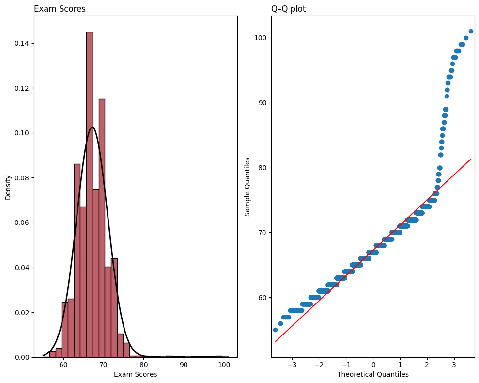

```python
distribution_plot(series = df['Exam_Score'], var_name = 'Exam Scores', save_path = FIG_DIR / 'ExamScoreDistribution')
```

The `Exam_Score` target feature shows a right skew with a majority of scores being concentrated in the range of 60-78 and a long tail stretching toward higher scores. Overall, both plots show the exam scores are unimodal, postively skewed, and not well modeled by a normal distribution.

### Numerical Distributions

#### `Hours_Studied`

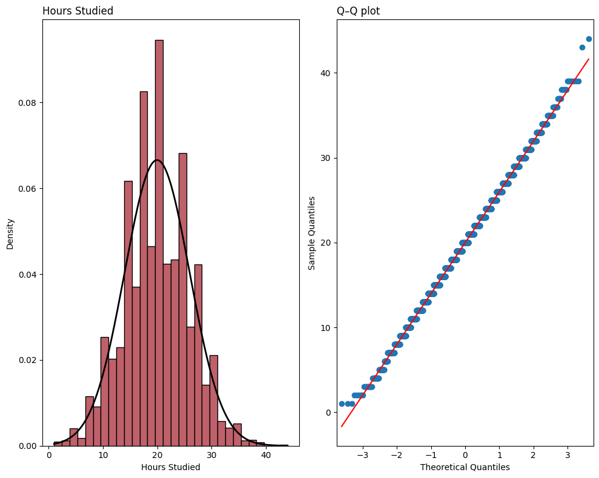

```python
distribution_plot(series = df['Hours_Studied'], var_name = 'Hours Studied', save_path = FIG_DIR / 'HoursStudiedDistribution')
```

These plots suggest `Hours_Studied` are normally distributed and centered around the low‑20s, with only mild tails at the extremes. The QQ plot is close to a straight line, so the distribution is approximately normal, with slight deviations in the tails.

#### `Attendance`

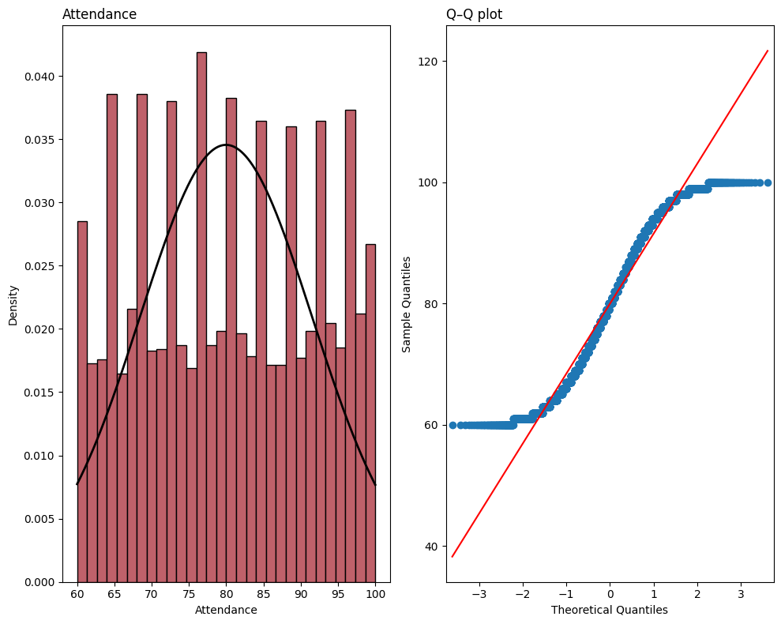

```python
distribution_plot(series = df['Attendance'], var_name = 'Attendance', save_path = FIG_DIR / 'AttendanceDistribution')
```

`Attendance` appears to show a roughly uniform distribution with no strong center vlaues. The QQ plot shows a distinct S-shaped curve rather than a straight line, suggesting that is is a flooring/ceiling effect occuring at values of 60 and 100 (The minimum and maximum values within the dataset).

#### `Sleep_Hours`

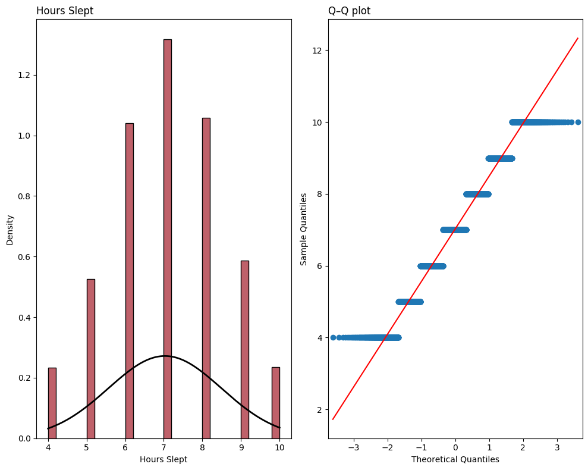

```python
distribution_plot(series = df['Sleep_Hours'], var_name = 'Hours Slept', save_path = FIG_DIR / 'HoursSleptDistribution')
```

`Sleep_Hours` shows a discrete distribution with values concentrated from 5 to 9 hours. The histogram and QQ plot show that the data is not continuous or normal.

#### `Previous_Scores`

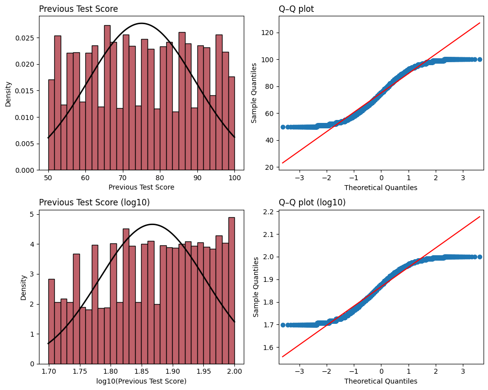

```python
distribution_plot(series = df['Previous_Scores'],
                  var_name = 'Previous Test Score',
                  transforms = {'log10' : lambda series : np.log10(series)},
                  save_path = FIG_DIR / 'PreviousExamScoreDistribution')
```

`Previous_Scores` shows a fairly uniform spread across score ranges of 50-100 and are not normally distributed. The QQ plot bends at both tails, indicating ceiling/flooring effects. The $log_{10}$ transformation does not improve normality, so the distribution remains non-normal even after transformation.

#### `Tutoring_Sessions`

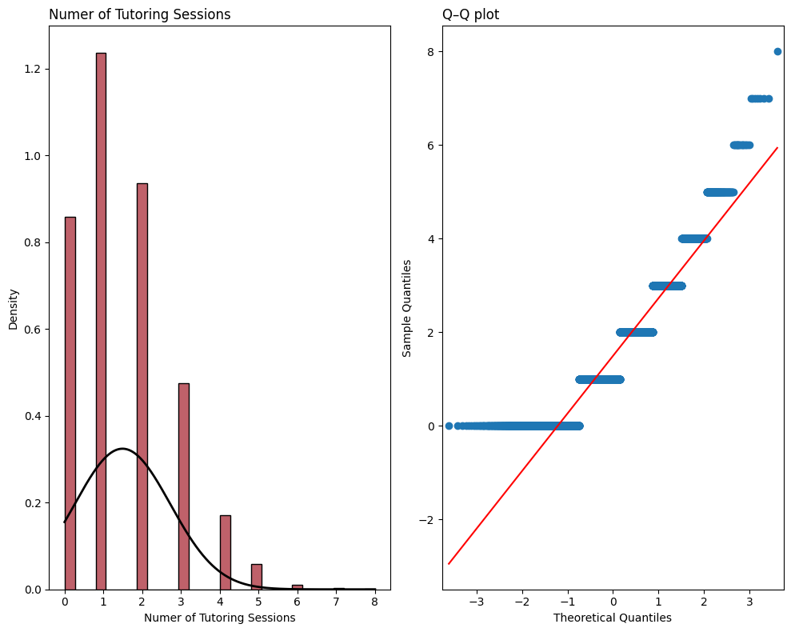

```python
distribution_plot(series = df['Tutoring_Sessions'], var_name = 'Numer of Tutoring Sessions', save_path = FIG_DIR / 'TutoringDistribution')
```

`Tutoring_Sessions` exhibits a discrete, right-skewed distribution with a substantial concentration at low values, including a notable concentration at zero. The QQ plot shows strong departures from normality due to the count-based and bounded nature of the variable rather than the presence of extreme outliers.

#### `Physical_Activity`

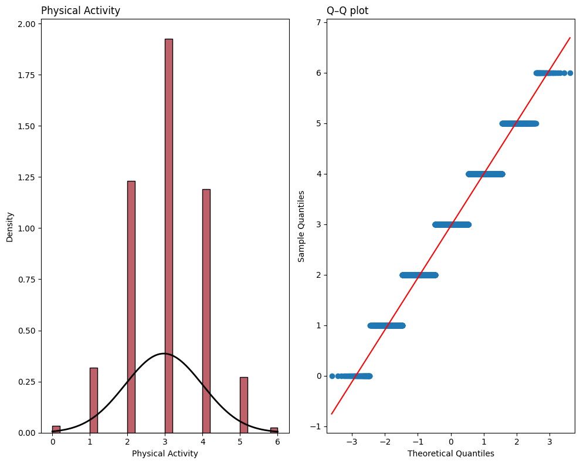

```python
distribution_plot(series = df['Physical_Activity'], var_name = 'Physical Activity', save_path = FIG_DIR / 'PhysicalDistribution')
```

`Physical_Activity` exhibits a discrete, bounded distribution with values concentrated at integer levels between 0 and 6. The distribution is approximately symmetric around moderate activity levels, while the QQ plot shows departures from normality driven by discrete values rather than skewness or outliers.

### Feature Engineering

There are no potential new features that can be derived from the current set of data.

### Bivariate Analysis

#### Hours study affects on exam score

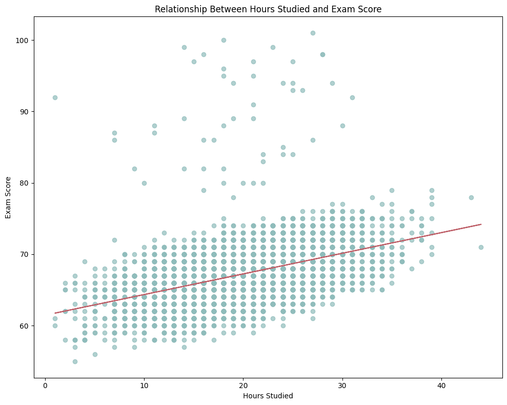

```python
exam_score = df['Exam_Score']
hours_studied = df['Hours_Studied']

# Calculate line of best fit
a, b = np.polyfit(x = hours_studied, y = exam_score, deg = 1)


fig, ax = plt.subplots(figsize = (10,8))
ax.scatter(x = hours_studied,
           y = exam_score,
           alpha = 0.7, color =
           fav_colors[1])
ax.plot(hours_studied, a * hours_studied + b, color = fav_colors[0])

ax.set_xlabel(xlabel = 'Hours Studied')
ax.set_ylabel(ylabel = 'Exam Score')
ax.set_title(label = 'Relationship Between Hours Studied and Exam Score')

plt.tight_layout()
plt.savefig(fname = FIG_DIR / 'HoursStudiedOnExamScore', dpi = 400)
plt.show()
plt.close('all')
```

The scatterplot illustrates a positive association between hours studied and exam score, with a fitted linear regression line idicating that increased study time is generally associated with higher exam performance. While, there is substantial variability in exam scores at each level of hours studied, the overall trend indicates a positive relationship between hours studied and exam score.

#### School Attedance on exam performance

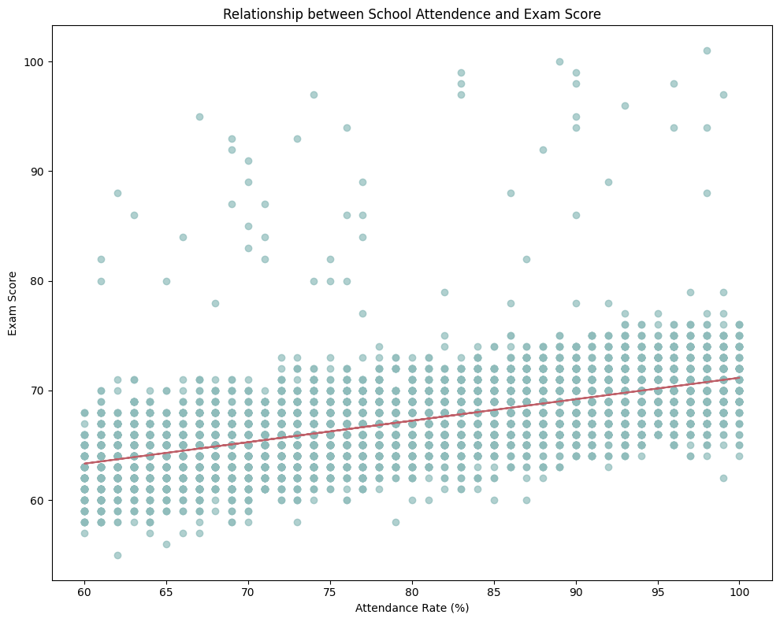

```python
attendance = df['Attendance']

# Line of best fit
a, b = np.polyfit(x = attendance, y = exam_score, deg = 1)

fig, ax = plt.subplots(figsize = (10, 8))
ax.scatter(x = attendance, y = exam_score, alpha = 0.7, color = fav_colors[1])
ax.plot(attendance, a * attendance + b, color = fav_colors[0])

ax.set_xlabel(xlabel = 'Attendance Rate (%)')
ax.set_ylabel(ylabel = 'Exam Score')
ax.set_title(label = 'Relationship between School Attendence and Exam Score')

plt.tight_layout()
plt.savefig(fname = FIG_DIR / 'SchoolAttendenceOnExamScore', dpi = 400)
plt.show()
plt.close('all')
```

Exam scores tend to increase with higher attendance rates, as indicated by the fitted linear trend, though considerable variability persists across the full range of attendance.

#### Parental Involvement and Exam Score

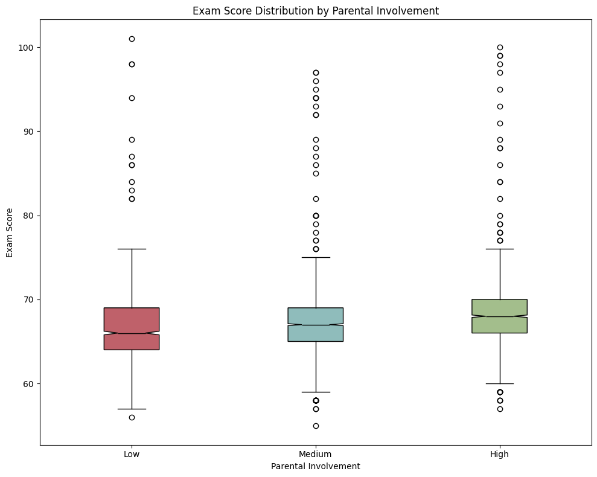

```python
low = exam_score.loc[df['Parental_Involvement'] == 'Low']
medium = exam_score.loc[df['Parental_Involvement'] == 'Medium']
high = exam_score.loc[df['Parental_Involvement'] == 'High']

fig, ax = plt.subplots(figsize = (10, 8))
bp = ax.boxplot(x = [low, medium, high],
                tick_labels = ['Low', 'Medium', 'High'],
                medianprops = dict(color = 'black'),
                notch = True,
                patch_artist = True)

for patch, color in zip(bp['boxes'], fav_colors):
    patch.set_facecolor(color)


ax.set_xlabel(xlabel = 'Parental Involvement')
ax.set_ylabel(ylabel = 'Exam Score')
ax.set_title(label = 'Exam Score Distribution by Parental Involvement')

plt.tight_layout()
plt.savefig(fname = FIG_DIR / 'InvovlementExamScore', dpi = 400)
plt.show()
plt.close()
```

Exam scores across all three levels of parental involvement occupy broadly similar ranges, indicating substantial overlap in performance regardless of involvement level. However, the median exam score increases from low to medium to high parental involvement. The notches representing approximate confidence intervals around the mediad show limited overlap between groups, suggesting systematic differences in central tendency. While higher parental involvement is associated with higher median exam scores, this relationship should be interpreted cautiously, as it is also plausible that students with stronger academic ability may require less parental involvement.

#### Resource Accessbility on Exam Scores

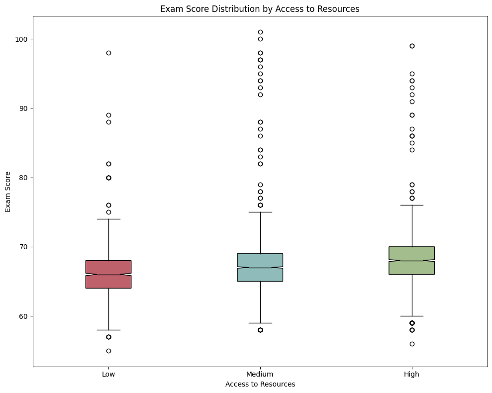

```python
low = df['Exam_Score'].loc[df['Access_to_Resources'] == 'Low']
medium = df['Exam_Score'].loc[df['Access_to_Resources'] == 'Medium']
high = df['Exam_Score'].loc[df['Access_to_Resources'] == 'High']

fig, ax = plt.subplots(figsize = (10, 8))
bp = ax.boxplot(x = [low, medium, high],
                tick_labels = ['Low', 'Medium', 'High'],
                notch = True,
                patch_artist = True,
                medianprops=dict(color='black'))

for patch, color in zip(bp['boxes'], fav_colors):
    patch.set_facecolor(color)

ax.set_xlabel(xlabel = 'Access to Resources')
ax.set_ylabel(ylabel = 'Exam Score')
ax.set_title(label = 'Exam Score Distribution by Access to Resources')

plt.tight_layout()
plt.show()
plt.savefig(fname = FIG_DIR / 'ResourceAcessExamScore', dpi = 400)
plt.close()
```

Exam scores span similar ranges across all levels of access to resources, indicating substantial overlap in observed performance. Nevertheless, median exam scores increase from low to medium to high access, with the notched confidence intervals around the medians suggesting systematic differences in central tendency.

Extracurricular Activities and Exam Score

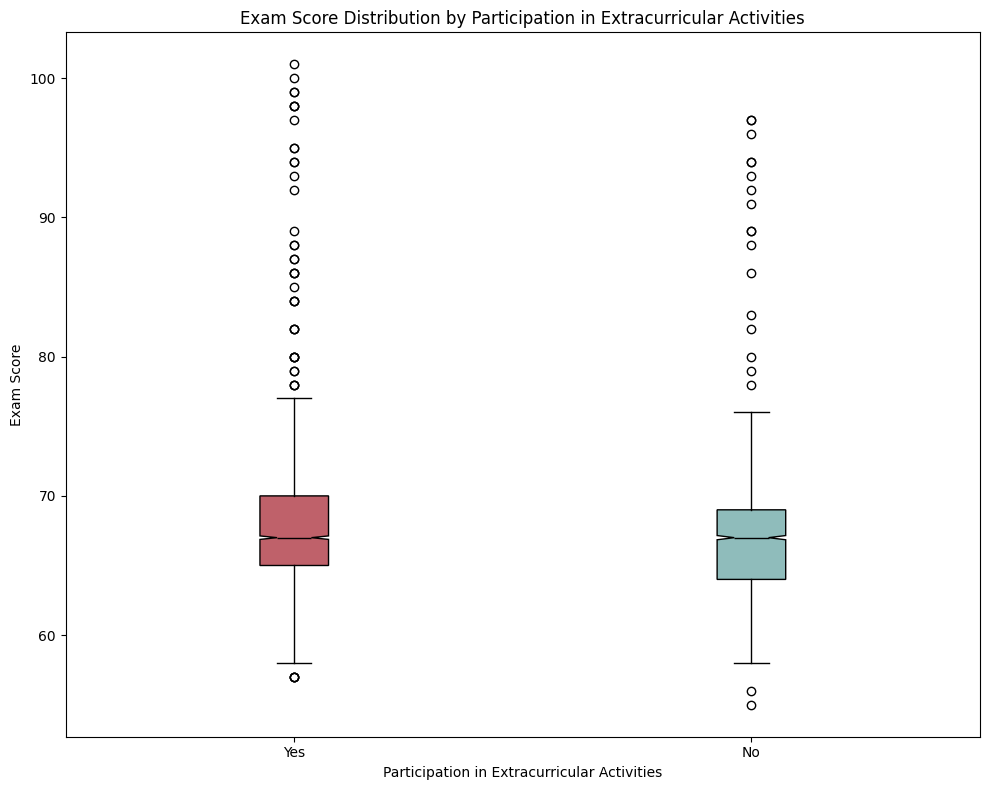

```python
act_yes = df['Exam_Score'].loc[df['Extracurricular_Activities'] == 'Yes']
act_no = df['Exam_Score'].loc[df['Extracurricular_Activities'] == 'No']

fig, ax = plt.subplots(figsize = (10, 8))
bp = ax.boxplot(x = [act_yes, act_no],
                tick_labels = ['Yes', 'No'],
                notch = True,
                medianprops = dict(color = 'black'),
                patch_artist = True)

for patch, color in zip(bp['boxes'], fav_colors):
    patch.set_facecolor(color)

ax.set_xlabel(xlabel = 'Participation in Extracurricular Activities')
ax.set_ylabel(ylabel = 'Exam Score')
ax.set_title(label = 'Exam Score Distribution by Participation in Extracurricular Activities')


plt.tight_layout()
plt.savefig(fname = FIG_DIR / 'ExtracurricularsExamScore', dpi = 400)
plt.show()
plt.close()
```

Exam score distributions for students who participate in extracurricular activities and those who do not are broadly similar, with nearly identical median values. However, the upper quartile (75th percentile) is slightly higher among students who participate, suggesting modest differences in higher-end performance. Substantial overlap across the full range of scores indicates that participation in extracurricular activities alone is not strongly differentiating overall exam outcomes.

#### Hours of Sleeps affect on Exam Score

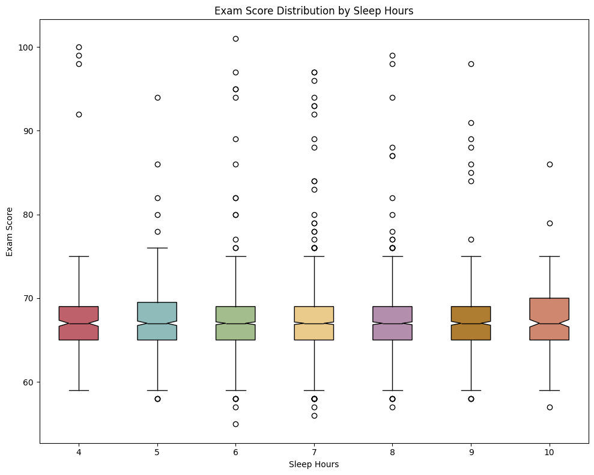

```python
sleep_4 = df['Exam_Score'].loc[df['Sleep_Hours'] == 4]
sleep_5 = df['Exam_Score'].loc[df['Sleep_Hours'] == 5]
sleep_6 = df['Exam_Score'].loc[df['Sleep_Hours'] == 6]
sleep_7 = df['Exam_Score'].loc[df['Sleep_Hours'] == 7]
sleep_8 = df['Exam_Score'].loc[df['Sleep_Hours'] == 8]
sleep_9 = df['Exam_Score'].loc[df['Sleep_Hours'] == 9]
sleep_10 = df['Exam_Score'].loc[df['Sleep_Hours'] == 10]


fig, ax = plt.subplots(figsize = (10, 8))
bp = ax.boxplot(x = [sleep_4, sleep_5, sleep_6, sleep_7, sleep_8, sleep_9, sleep_10],
                tick_labels = ['4', '5', '6', '7', '8', '9', '10'],
                notch = True,
                medianprops = dict(color = 'black'),
                patch_artist = True)

for patch, color in zip(bp['boxes'], fav_colors):
    patch.set_facecolor(color)

ax.set_xlabel(xlabel = 'Sleep Hours')
ax.set_ylabel(ylabel = 'Exam Score')
ax.set_title(label = 'Exam Score Distribution by Sleep Hours')


plt.tight_layout()
plt.savefig(fname = FIG_DIR / 'SleepHoursExamScore', dpi = 400)
plt.show()
plt.close()
```

#### Previous Test Score on Exam Score

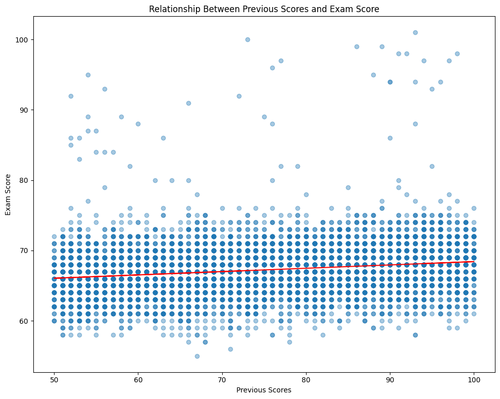

```python
prev_scores = df['Previous_Scores']
exam_score = df['Exam_Score']

m, b = np.polyfit(prev_scores, exam_score, 1)


fig, ax = plt.subplots(figsize = (10, 8))
ax.scatter(x = prev_scores,
           y = exam_score,
           alpha = 0.4)
ax.plot(prev_scores,
        m * prev_scores + b,
        color = 'red')


ax.set_xlabel(xlabel = 'Previous Scores')
ax.set_ylabel(ylabel = 'Exam Score')
ax.set_title(label = 'Relationship Between Previous Scores and Exam Score')


plt.tight_layout()
plt.savefig(fname = FIG_DIR / 'PreviousScoresExamScore', dpi = 400)
plt.show()
plt.close()
```

The scatter plot shows a a mild positive association between previous scores and exam score, as indicated by the fitted linear regression line. However, the relationship is relatively shallow, with substantial variability in exam scores observed across the full range of previous scores. While higher prior performance is associated with slightly higher exam outcomes on average, previous scores alone do not strongly determine current exam performance, suggesting that additional factors contribute meaningfully to observed variability.

#### Motivation Levels Affect on Exam Score

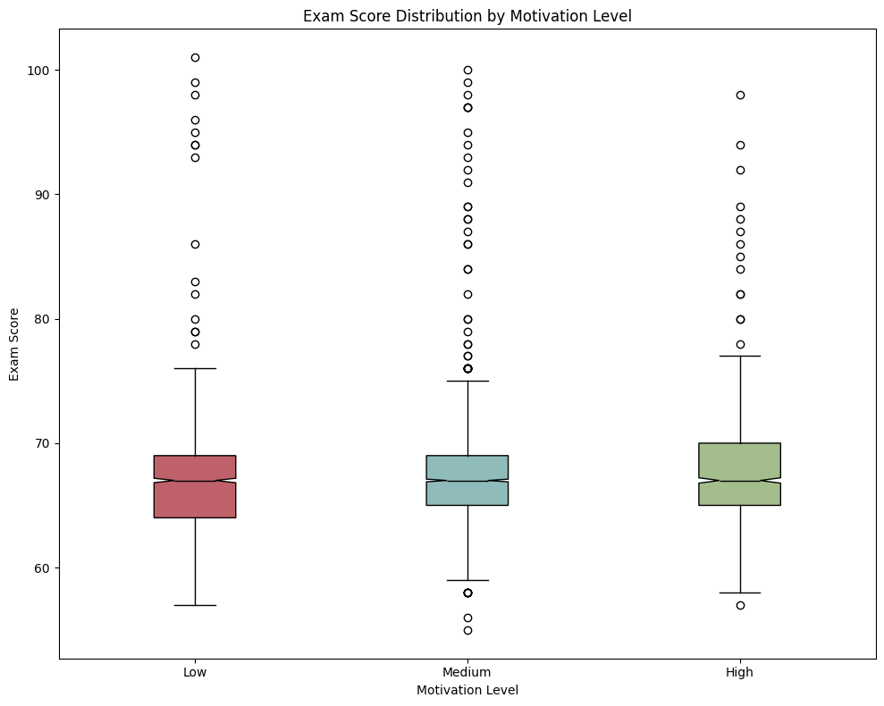

```python
mot_low = df['Exam_Score'].loc[df['Motivation_Level'] == 'Low']
mot_medium = df['Exam_Score'].loc[df['Motivation_Level'] == 'Medium']
mot_high = df['Exam_Score'].loc[df['Motivation_Level'] == 'High']


fig, ax = plt.subplots(figsize = (10, 8))
bp = ax.boxplot(x = [mot_low, mot_medium, mot_high],
                tick_labels = ['Low', 'Medium', 'High'],
                notch = True,
                medianprops = dict(color = 'black'),
                patch_artist = True)

for patch, color in zip(bp['boxes'], fav_colors):
    patch.set_facecolor(color)

ax.set_xlabel(xlabel = 'Motivation Level')
ax.set_ylabel(ylabel = 'Exam Score')
ax.set_title(label = 'Exam Score Distribution by Motivation Level')


plt.tight_layout()
plt.savefig(fname = FIG_DIR / 'MotivationLevelExamScore', dpi = 400)
plt.show()
plt.close()
```

Exam score distributions across motivation levels exhibit substantial overlap, with broadly similar ranges of observed values. Median exam scores do not appear to increase across different motivation levels.

#### Internet Access and Exam Score

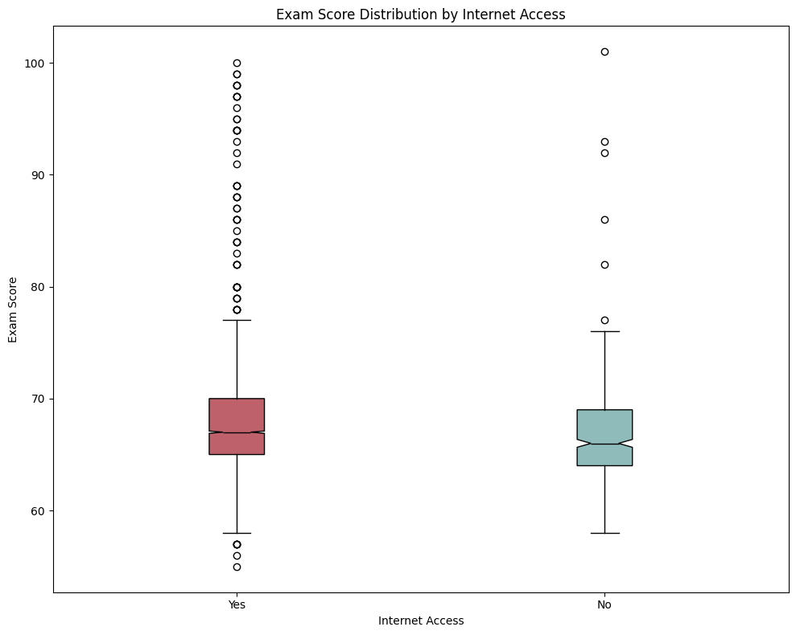

```python
int_yes = df['Exam_Score'].loc[df['Internet_Access'] == 'Yes']
int_no = df['Exam_Score'].loc[df['Internet_Access'] == 'No']


fig, ax = plt.subplots(figsize = (10, 8))
bp = ax.boxplot(x = [int_yes, int_no],
                tick_labels = ['Yes', 'No'],
                notch = True,
                medianprops = dict(color = 'black'),
                patch_artist = True)

for patch, color in zip(bp['boxes'], fav_colors):
    patch.set_facecolor(color)

ax.set_xlabel(xlabel = 'Internet Access')
ax.set_ylabel(ylabel = 'Exam Score')
ax.set_title(label = 'Exam Score Distribution by Internet Access')


plt.tight_layout()
plt.savefig(fname = FIG_DIR / 'InternetAccessExamScore', dpi = 400)
plt.show()
plt.close()
```

Exam score distributions for students with and without internet access show substantial overlap, with similar overall ranges of observed values. Median exam scores are slightly higher among students with internet access, as indicated by the notched confidence intervals around the medians, though the difference is modest.

#### Tutoring Sessions and Exam Score

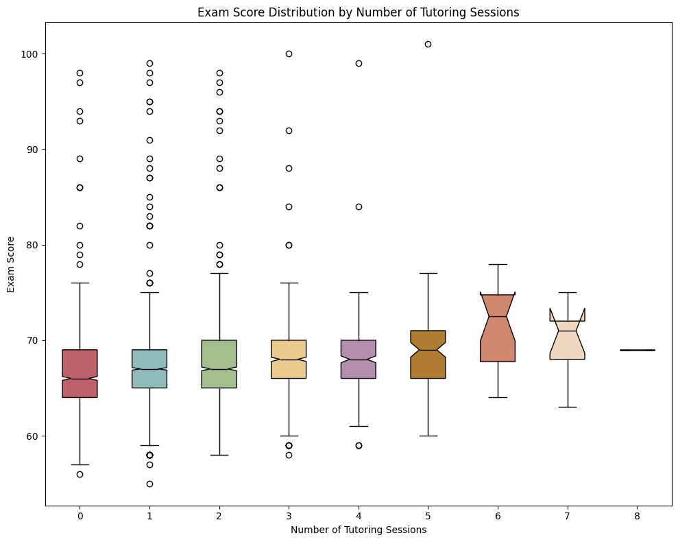

```python
tut_0 = df['Exam_Score'].loc[df['Tutoring_Sessions'] == 0]
tut_1 = df['Exam_Score'].loc[df['Tutoring_Sessions'] == 1]
tut_2 = df['Exam_Score'].loc[df['Tutoring_Sessions'] == 2]
tut_3 = df['Exam_Score'].loc[df['Tutoring_Sessions'] == 3]
tut_4 = df['Exam_Score'].loc[df['Tutoring_Sessions'] == 4]
tut_5 = df['Exam_Score'].loc[df['Tutoring_Sessions'] == 5]
tut_6 = df['Exam_Score'].loc[df['Tutoring_Sessions'] == 6]
tut_7 = df['Exam_Score'].loc[df['Tutoring_Sessions'] == 7]
tut_8 = df['Exam_Score'].loc[df['Tutoring_Sessions'] == 8]


fig, ax = plt.subplots(figsize = (10, 8))
bp = ax.boxplot(x = [tut_0, tut_1, tut_2, tut_3, tut_4, tut_5, tut_6, tut_7, tut_8],
                tick_labels = ['0', '1', '2', '3', '4', '5', '6', '7', '8'],
                notch = True,
                medianprops = dict(color = 'black'),
                patch_artist = True)

for patch, color in zip(bp['boxes'], fav_colors):
    patch.set_facecolor(color)

ax.set_xlabel(xlabel = 'Number of Tutoring Sessions')
ax.set_ylabel(ylabel = 'Exam Score')
ax.set_title(label = 'Exam Score Distribution by Number of Tutoring Sessions')


plt.tight_layout()
plt.savefig(fname = FIG_DIR / 'TutoringSessionsExamScore', dpi = 400)
plt.show()
plt.close()
```

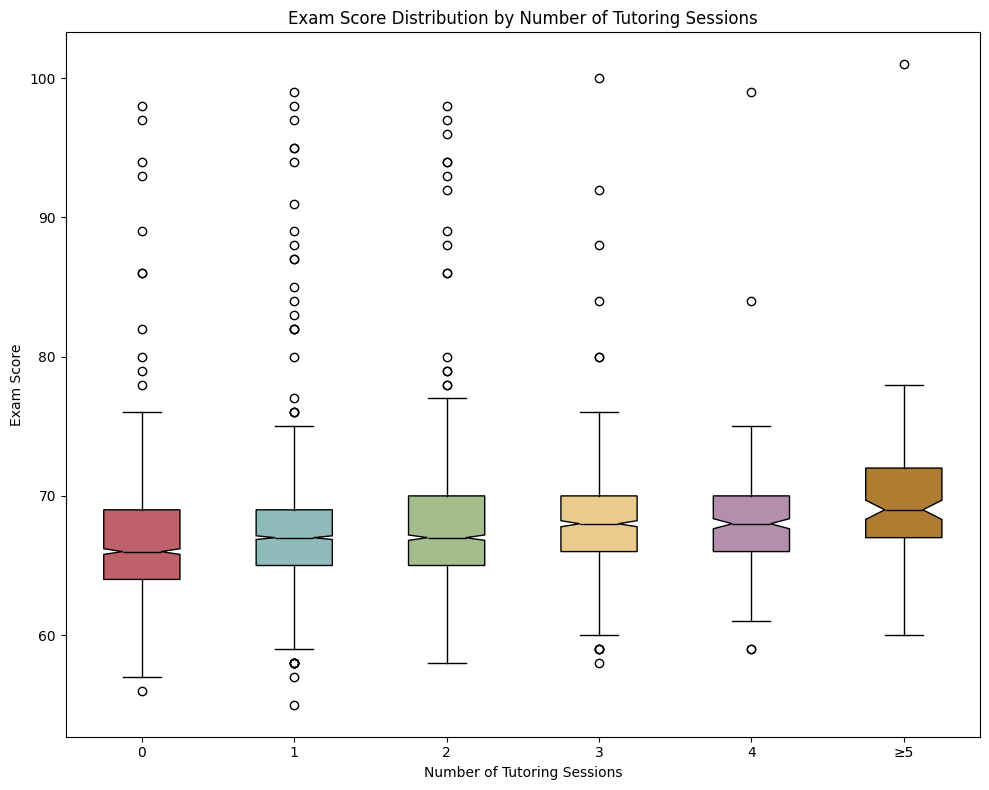

```python
tut_0 = df['Exam_Score'].loc[df['Tutoring_Sessions'] == 0]
tut_1 = df['Exam_Score'].loc[df['Tutoring_Sessions'] == 1]
tut_2 = df['Exam_Score'].loc[df['Tutoring_Sessions'] == 2]
tut_3 = df['Exam_Score'].loc[df['Tutoring_Sessions'] == 3]
tut_4 = df['Exam_Score'].loc[df['Tutoring_Sessions'] == 4]
tut_5 = df['Exam_Score'].loc[df['Tutoring_Sessions'] >= 5]


fig, ax = plt.subplots(figsize = (10, 8))
bp = ax.boxplot(x = [tut_0, tut_1, tut_2, tut_3, tut_4, tut_5],
                tick_labels = ['0', '1', '2', '3', '4', '≥5'],
                notch = True,
                medianprops = dict(color = 'black'),
                patch_artist = True)

for patch, color in zip(bp['boxes'], fav_colors):
    patch.set_facecolor(color)

ax.set_xlabel(xlabel = 'Number of Tutoring Sessions')
ax.set_ylabel(ylabel = 'Exam Score')
ax.set_title(label = 'Exam Score Distribution by Number of Tutoring Sessions')


plt.tight_layout()
plt.savefig(fname = FIG_DIR / 'TutoringSessionsExamScore_Collapsed', dpi = 400)
plt.show()
plt.close()
```

Exam score distributions exhibit a gradual upward shift in median values as the number of tutoring sessions increases. Although score ranges overlap substantially across categories, median exam scores increase modestly from zero through four tutoring sessions, with the highest median observed among students receiving five or more sessions. The considerable overlap in interquartile ranges indicates that tutoring frequency alone does not fully explain exam performance, but the monotonic increase in medians suggests a positive association.

#### Family Income and Exam Score

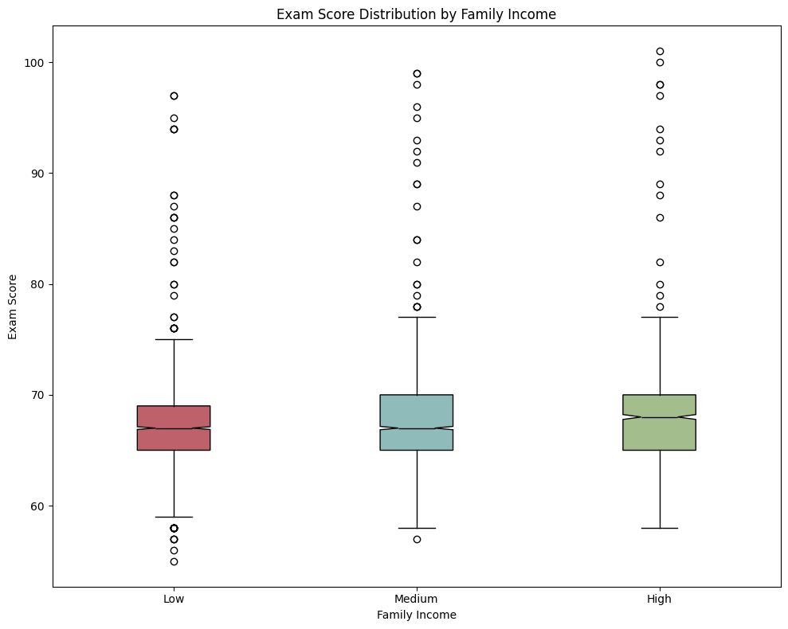

```python
inc_low = df['Exam_Score'].loc[df['Family_Income'] == 'Low']
inc_medium = df['Exam_Score'].loc[df['Family_Income'] == 'Medium']
inc_high = df['Exam_Score'].loc[df['Family_Income'] == 'High']


fig, ax = plt.subplots(figsize = (10, 8))
bp = ax.boxplot(x = [inc_low, inc_medium, inc_high],
                tick_labels = ['Low', 'Medium', 'High'],
                notch = True,
                medianprops = dict(color = 'black'),
                patch_artist = True)

for patch, color in zip(bp['boxes'], fav_colors):
    patch.set_facecolor(color)

ax.set_xlabel(xlabel = 'Family Income')
ax.set_ylabel(ylabel = 'Exam Score')
ax.set_title(label = 'Exam Score Distribution by Family Income')


plt.tight_layout()
plt.savefig(fname = FIG_DIR / 'FamilyIncomeExamScore', dpi = 400)
plt.show()
plt.close()
```

Exam score distribution do not appear to be too different between low and medium family income. High family income appears to have a slightly higher median value compared to students from medium and low income households. Overall, the distributions do not appear to be strongly correlated with exam performance.

#### Type of School on Exam Score

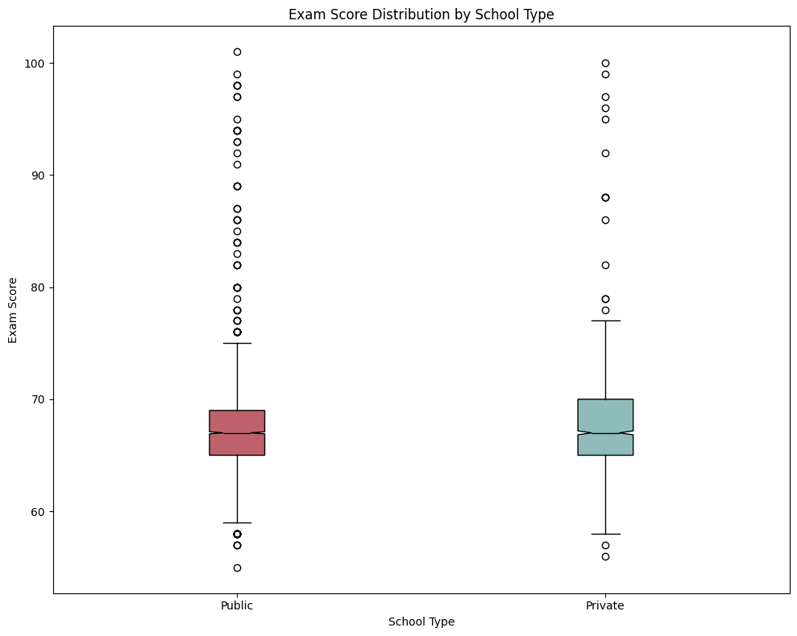

```python
sch_public = df['Exam_Score'].loc[df['School_Type'] == 'Public']
sch_private = df['Exam_Score'].loc[df['School_Type'] == 'Private']


fig, ax = plt.subplots(figsize = (10, 8))
bp = ax.boxplot(x = [sch_public, sch_private],
                tick_labels = ['Public', 'Private'],
                notch = True,
                medianprops = dict(color = 'black'),
                patch_artist = True)

for patch, color in zip(bp['boxes'], fav_colors):
    patch.set_facecolor(color)

ax.set_xlabel(xlabel = 'School Type')
ax.set_ylabel(ylabel = 'Exam Score')
ax.set_title(label = 'Exam Score Distribution by School Type')


plt.tight_layout()
plt.savefig(fname = FIG_DIR / 'SchoolTypeExamScore', dpi = 400)
plt.show()
plt.close()
```

Exam score distributions for public and private schools are highly similar, with nearly identical median values and overlapping interquartile ranges. Both groups occupy comparable ranges of exam scores, suggesting no meaningful difference in central tendency between school types. The public school group exhibits a greater number of outliers, likely reflecting its larger sample size rather than a systematic difference in performance.

#### Teacher Quality on Exam Score

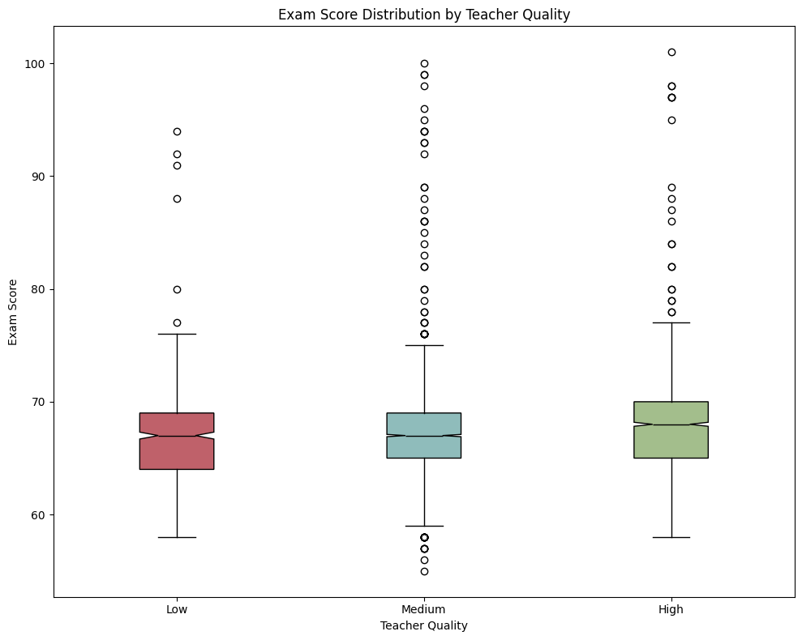

```python
tq_low = df['Exam_Score'].loc[df['Teacher_Quality'] == 'Low']
tq_medium = df['Exam_Score'].loc[df['Teacher_Quality'] == 'Medium']
tq_high = df['Exam_Score'].loc[df['Teacher_Quality'] == 'High']


fig, ax = plt.subplots(figsize = (10, 8))
bp = ax.boxplot(x = [tq_low, tq_medium, tq_high],
                tick_labels = ['Low', 'Medium', 'High'],
                notch = True,
                medianprops = dict(color = 'black'),
                patch_artist = True)

for patch, color in zip(bp['boxes'], fav_colors):
    patch.set_facecolor(color)

ax.set_xlabel(xlabel = 'Teacher Quality')
ax.set_ylabel(ylabel = 'Exam Score')
ax.set_title(label = 'Exam Score Distribution by Teacher Quality')


plt.tight_layout()
plt.savefig(fname = FIG_DIR / 'TeacherQualityExamScore', dpi = 400)
plt.show()
plt.close()
```

Exam score distributions are largely similar across teacher quality levels, with substantial overlap in interquartile ranges. Students taught by high-quality teachers exhibit a slightly higher median exam score; however, the overlap of notched confidence intervals suggests that differences in central tendency are modest. The medium teacher quality group displays a comparatively tighter interquartile range but a greater number of outliers, indicating increased variability in extreme outcomes rather than differences in typical performance

#### Peer Influence on Exam Score

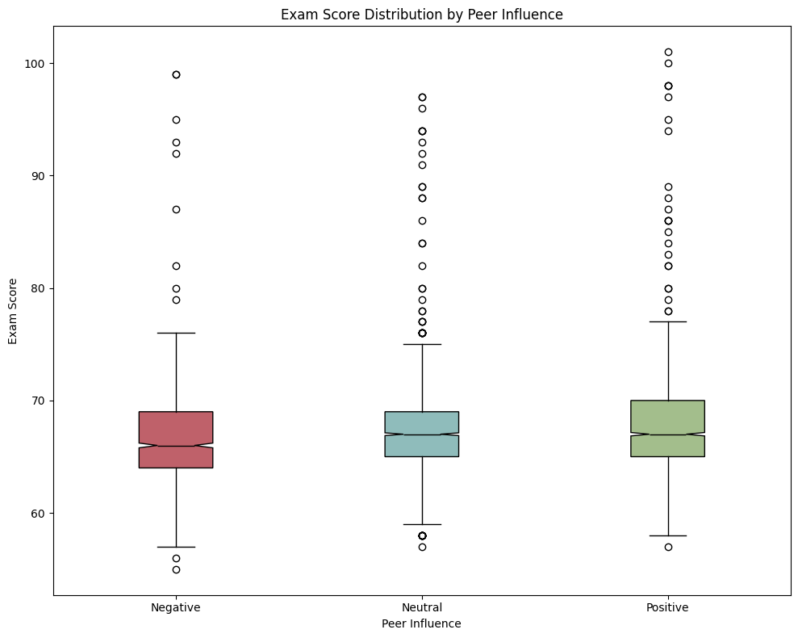

```python
peer_negative = df['Exam_Score'].loc[df['Peer_Influence'] == 'Negative']
peer_neutral = df['Exam_Score'].loc[df['Peer_Influence'] == 'Neutral']
peer_positive = df['Exam_Score'].loc[df['Peer_Influence'] == 'Positive']


fig, ax = plt.subplots(figsize = (10, 8))
bp = ax.boxplot(x = [peer_negative, peer_neutral, peer_positive],
                tick_labels = ['Negative', 'Neutral', 'Positive'],
                notch = True,
                medianprops = dict(color = 'black'),
                patch_artist = True)

for patch, color in zip(bp['boxes'], fav_colors):
    patch.set_facecolor(color)

ax.set_xlabel(xlabel = 'Peer Influence')
ax.set_ylabel(ylabel = 'Exam Score')
ax.set_title(label = 'Exam Score Distribution by Peer Influence')


plt.tight_layout()
plt.savefig(fname = FIG_DIR / 'PeerInfluenceExamScore', dpi = 400)
plt.show()
plt.close()
```

Exam score distributions are highly similar across peer influence categories, with nearly identical medians and substantial overlap in interquartile ranges. All three groups occupy comparable score ranges, and no clear separation in central tendency or spread is observed. These results suggest that peer influence, as measured here, is not strongly associated with exam performance.

#### Physical Acitvity

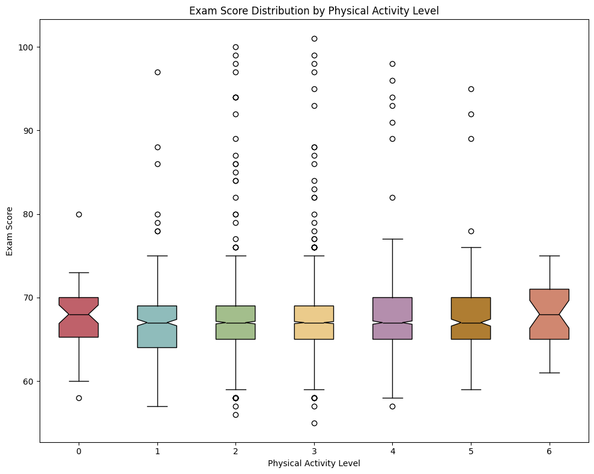

```python
pa_0 = df['Exam_Score'].loc[df['Physical_Activity'] == 0]
pa_1 = df['Exam_Score'].loc[df['Physical_Activity'] == 1]
pa_2 = df['Exam_Score'].loc[df['Physical_Activity'] == 2]
pa_3 = df['Exam_Score'].loc[df['Physical_Activity'] == 3]
pa_4 = df['Exam_Score'].loc[df['Physical_Activity'] == 4]
pa_5 = df['Exam_Score'].loc[df['Physical_Activity'] == 5]
pa_6 = df['Exam_Score'].loc[df['Physical_Activity'] == 6]


fig, ax = plt.subplots(figsize = (10, 8))
bp = ax.boxplot(x = [pa_0, pa_1, pa_2, pa_3, pa_4, pa_5, pa_6],
                tick_labels = ['0', '1', '2', '3', '4', '5', '6'],
                notch = True,
                medianprops = dict(color = 'black'),
                patch_artist = True)

for patch, color in zip(bp['boxes'], fav_colors):
    patch.set_facecolor(color)

ax.set_xlabel(xlabel = 'Physical Activity Level')
ax.set_ylabel(ylabel = 'Exam Score')
ax.set_title(label = 'Exam Score Distribution by Physical Activity Level')


plt.tight_layout()
plt.savefig(fname = FIG_DIR / 'PhysicalActivityExamScore', dpi = 400)
plt.show()
plt.close()
```

Exam score distributions are highly similar across physical activity levels, with overlapping interquartile ranges and nearly identical medians. The notched confidence intervals around the medians overlap substantially across all activity levels, indicating no clear difference in central tendency. These results suggest that physical activity level, as measured here, is not strongly associated with exam performance.

#### Learning Disabilites on Exam Score

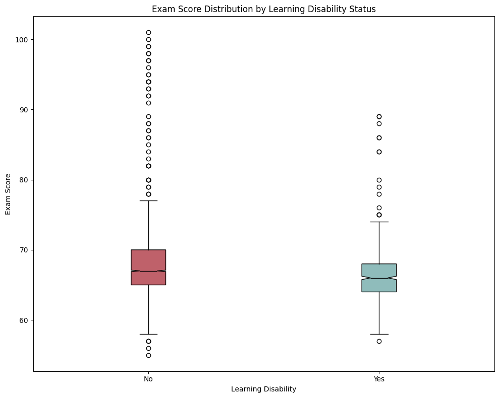

```python
ld_no = df['Exam_Score'].loc[df['Learning_Disabilities'] == 'No']
ld_yes = df['Exam_Score'].loc[df['Learning_Disabilities'] == 'Yes']


fig, ax = plt.subplots(figsize = (10, 8))
bp = ax.boxplot(x = [ld_no, ld_yes],
                tick_labels = ['No', 'Yes'],
                notch = True,
                medianprops = dict(color = 'black'),
                patch_artist = True)

for patch, color in zip(bp['boxes'], fav_colors):
    patch.set_facecolor(color)

ax.set_xlabel(xlabel = 'Learning Disability')
ax.set_ylabel(ylabel = 'Exam Score')
ax.set_title(label = 'Exam Score Distribution by Learning Disability Status')


plt.tight_layout()
plt.savefig(fname = FIG_DIR / 'LearningDisabilityExamScore', dpi = 400)
plt.show()
plt.close()
```

Exam score distributions differ modestly by learning disability status. Students without reported learning disabilities exhibit a slightly higher median exam score and a wider upper tail of high scoring outliers. Students with reported learning disabilities show a somewhat lower median and a more compact distribution. However, substantial overlap in interquartile ranges indicates that exam performance varies widely within both groups, and learning disability status alone does not fully explain differences in exam outcomes.

#### Parental Education Level on Exam Score

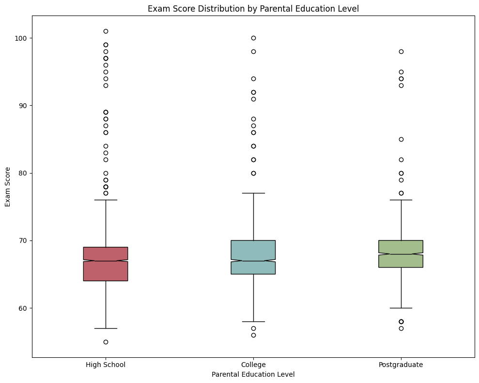

```python
edu_hs = df['Exam_Score'].loc[df['Parental_Education_Level'] == 'High School']
edu_col = df['Exam_Score'].loc[df['Parental_Education_Level'] == 'College']
edu_post = df['Exam_Score'].loc[df['Parental_Education_Level'] == 'Postgraduate']


fig, ax = plt.subplots(figsize = (10, 8))
bp = ax.boxplot(x = [edu_hs, edu_col, edu_post],
                tick_labels = ['High School', 'College', 'Postgraduate'],
                notch = True,
                medianprops = dict(color = 'black'),
                patch_artist = True)

for patch, color in zip(bp['boxes'], fav_colors):
    patch.set_facecolor(color)

ax.set_xlabel(xlabel = 'Parental Education Level')
ax.set_ylabel(ylabel = 'Exam Score')
ax.set_title(label = 'Exam Score Distribution by Parental Education Level')


plt.tight_layout()
plt.savefig(fname = FIG_DIR / 'ParentalEducationExamScore', dpi = 400)
plt.show()
plt.close()
```

Exam score distributions vary modestly across parental education levels. Students with postgraduate-educated parents exhibit a slightly higher median exam score and a tighter interquartile range, suggesting more consistent performance within this group. Students whose parents have a high school education show a wider lower tail, with a lower first quartile compared to the college group, indicating greater variability in lower exam scores. Despite these differences, substantial overlap in distributions remains across all education levels.

#### Distance from Home on Exam Score

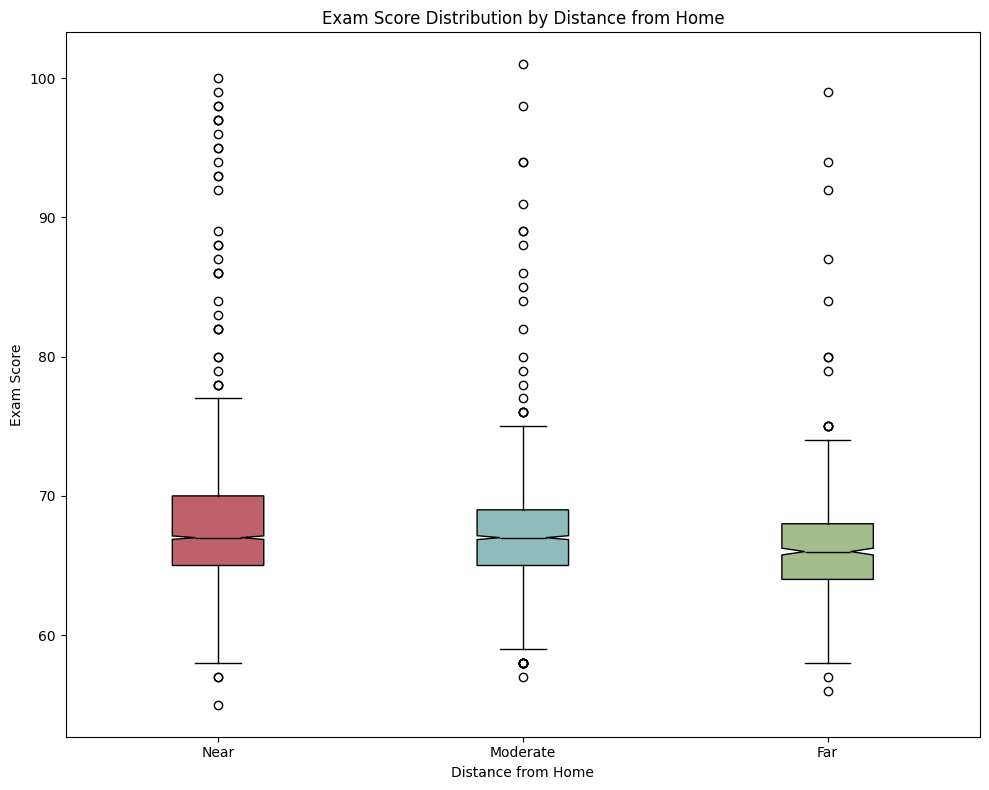

```python
dist_near = df['Exam_Score'].loc[df['Distance_from_Home'] == 'Near']
dist_moderate = df['Exam_Score'].loc[df['Distance_from_Home'] == 'Moderate']
dist_far = df['Exam_Score'].loc[df['Distance_from_Home'] == 'Far']


fig, ax = plt.subplots(figsize = (10, 8))
bp = ax.boxplot(x = [dist_near, dist_moderate, dist_far],
                tick_labels = ['Near', 'Moderate', 'Far'],
                notch = True,
                medianprops = dict(color = 'black'),
                patch_artist = True)

for patch, color in zip(bp['boxes'], fav_colors):
    patch.set_facecolor(color)

ax.set_xlabel(xlabel = 'Distance from Home')
ax.set_ylabel(ylabel = 'Exam Score')
ax.set_title(label = 'Exam Score Distribution by Distance from Home')


plt.tight_layout()
plt.savefig(fname = FIG_DIR / 'DistanceFromHomeExamScore', dpi = 400)
plt.show()
plt.close()
```

Exam score distributions show a modest downward shift in median values as distance from home increases. Students living farther from school exhibit slightly lower median exam scores compared to those living near or at a moderate distance. Although score distributions overlap substantially across groups, the far distance group displays a lower central tendency, suggesting a weak negative association between distance from home and exam performance.

#### Gender and Exam Score

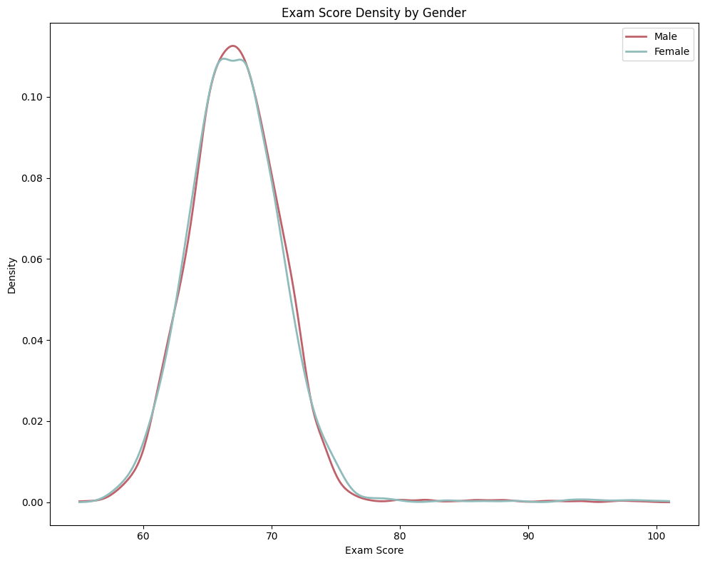

```python
from scipy.stats import gaussian_kde
import numpy as np

male   = df['Exam_Score'].loc[df['Gender'] == 'Male']
female = df['Exam_Score'].loc[df['Gender'] == 'Female']

x_vals = np.linspace(df['Exam_Score'].min(), df['Exam_Score'].max(), 500)
kde_male   = gaussian_kde(male)
kde_female = gaussian_kde(female)


fig, ax = plt.subplots(figsize = (10, 8))
ax.plot(x_vals, kde_male(x_vals),
        color = fav_colors[0],
        label = 'Male',
        linewidth = 2)
ax.plot(x_vals, kde_female(x_vals),
        color = fav_colors[1],
        label = 'Female',
        linewidth = 2)


ax.set_xlabel(xlabel = 'Exam Score')
ax.set_ylabel(ylabel = 'Density')
ax.set_title(label = 'Exam Score Density by Gender')
ax.legend()


plt.tight_layout()
plt.savefig(fname = FIG_DIR / 'ExamScoreDensityByGender', dpi = 400)
plt.show()
plt.close()
```

The kernel density estimates for exam scores by gender show near-complete overlap, indicating no meaningful differences in score distributions between male and female students

### Correlation Heatmap

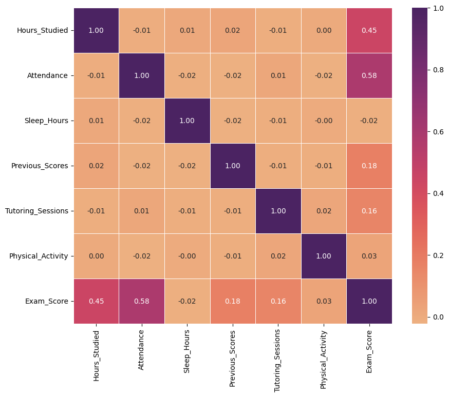

```python
heat_map = df.select_dtypes(include = [np.number]).corr()

fig, ax = plt.subplots(figsize = (10, 8))
sns.heatmap(data = heat_map, annot = True, cmap = 'flare', fmt='.2f', linewidths=.5)
```

The correlation heatmap highlights several meaningful relationships between numerical predictors and Exam_Score. The strongest positive associations are observed for Attendance (r $\approx$ 0.58) and Hours_Studied (r $\approx$ 0.45), indicating that students who attend classes more consistently and dedicate more time to studying tend to achieve higher exam scores. These two variables appear to be the primary drivers of performance in the dataset. More modest positive correlations are observed for Previous_Scores (r $\approx$ 0.18) and Tutoring_Sessions (r $\approx$ 0.16). While these relationships are weaker, they suggest that prior academic performance and additional academic support contribute incrementally to exam outcomes. All other variables show near-zero correlations with exam scores.

## Model Selection

The objective of this analysis is to predict `Exam_Score`, a continuous outcome variable, using a combination of predictors. As such, this task is framed as a supervised regression problem. A diverse set of regression models will be selected to balance interpretability, predictive performance, and model complexity. To allow comparison across models, all candidate models will be evaluated using the same train–test split and cross-validation strategy, and performance is assessed using consistent evaluation metrics.

### Baseline Model: Dummy Regressor

A dummy regression model that predicts the mean exam score from the training data is used as a baseline comparisons. The model will not utilize any predictor information and serves as a minimum performance benchmark, to allow assessment of whether more complex models offer significant improvements over basic rules (i.e., mean value). Ideally, all other models should outperform this baseline to be considered useful.

No hyperparameters will be tuned for this model.

### Linear Regression

Ordinary Least Squares (OLS) regression is used as a primary baseline model due to its interpretability. The model assumes a linear relationship between predictors and the outcome variable:

$$y = \beta_0 + \sum_{j=1}^{p} \beta_j x_j + \varepsilon$$

where $y$ is the exam score, $x_j$ are the predictor variables, $\beta_j$ are regression coefficients, and $\varepsilon$ is the error term.

Linear regression provides interpretable coefficient estimates that quantify the association between each predictor and exam score. Linear models assume that there is a linear relationship between variables, independence between residuals for different observations, constant variance, a normal distribution of residuals, and no multicollinearity between predictors.

No hyperparameters will be tuned for this model.

### Lasso Regression

Lasso (Least Absolute Shrinkage and Selection Operator) regression extends ordinary linear regression by introducing an L1 regularization penalty, which encourages sparsity in the model coefficients. Lasso is capable of shrinking non-useful coefficients exactly to zero while maintaining useful features, effectively performing implicit feature selection.

$$ \min_{\beta}\left( \sum_{i=1}^{n}\left(y_i-\hat{y}_i\right)^2 +\lambda\sum_{j=1}^{p}\left|\beta_j\right| \right) $$

Lasso regression is particularly useful in settings where a subset of predictors may contribute little to predictive performance, or where interpretability and model parsimony are of interest. Given the inclusion of numerous categorical predictors expanded via one-hot encoding, Lasso provides a mechanism to assess whether a sparse linear representation improves generalization performance.

Hyperparameters:

- $\lambda$ (Regularization Strength) - Controls the penalty applied to coefficients. As $\lambda$ increases the model shrinks coefficients to zero (Thus reducing variance but increasing bias).

### Ridge Regression

Ridge regression is an extension of linear regression that utilizes L2 regularization, by adding a penalty term to the cost function that shrinks coefficients toward zero. This address multicollinearity between predictors by adding a small amount of bias to the regression estimates to reduce variance, in turn providing more stable and reliable models:

$$\min_{\beta}\left( \sum_{i=1}^{n}\left(y_i-\hat{y}_i\right)^2 +\lambda\sum_{j=1}^{p}\beta_j^{2} \right)$$

Ridge regression performs well in datasets with many correlated predictors.

Hyperparameters:

- $\lambda$ (Regularization Strength) - Controls the penalty applied to coefficients. As $\lambda$ increases the model shrinks coefficients to zero (Thus reducing variance but increasing bias).

### Elastic Net Regression

Elastic net regression is another extension of the linear model that combines both L1 (Lasso) and L2 (Ridge) penalties, allowing for coefficient shrinkage and potential feature selection:

$$\min_{\beta}\left( \sum_{i=1}^{n}\left(y_i-\hat{y}_i\right)^2 +\lambda\left[ \alpha\sum_{j=1}^{p}\lvert\beta_j\rvert +(1-\alpha)\sum_{j=1}^{p}\beta_j^{2} \right] \right)$$

Elastic net regression is suited for datasets containing many predictors, but only a few of the features are considered to be important.

Hyperparameters:

- $\lambda$ - Controls the penalty applied to coefficients. As $\lambda$ increases the model shrinks coefficients to zero (Thus reducing variance but increasing bias).
- $\alpha$ - Dictates the mix between L1 and L2 penalties. $\alpha$ ranges from 0 to 1, where $\alpha$ = 0 is a pure ridge model and $\alpha$ = 1 is a pure lasso model

### Support Vector Regression (SVR)

Support Vector Regression is a ernel-based method that can model nonlinear relationships between features and the outcome variable. SVR is a supervised machine learning method that predicts value by finding the best fit hyperplane with a defined margin of tolerance ($\epsilon$).

Hyperparamters:

- $C$ - Regularization parameter that defines the trade-off between maximizing the margin and minimizing training errors. A higher $C$ penalizes larger errors, leading to a narrow margin, while smaller $C$ values have lower penalities leading to a bigger margin and more deviations.
- $\epsilon$ - Defines a margin ('width') of around the regression line where no penalty is applied to errors. Larger values create a wider margin
- Keranl-specific parameters

SVR is sensitive to feature scaling and is included to capture potential nonlinear effects no addressed by linear models.

### Decision Tree Regression

Decision Tree Regression is a nonparametric model that recursively partitions the feature space into regions with similar target values. Trees are able to capture nonlinear relationships and interactions without requiring feature scaling.

Hyperparameters:

- Tree Depth - Controls the maximum depth of a tree. Shallow trees tend to be too simple to capture complex relationships, while deep trees can be overfit to the training data (Low bias, high variance).
- Minimum samples per split - Controls the minimum number of samples a node must have before it can be divided. Low values will cause the tree to split on noisy subsets (Overfitting), while high values will force the tree to split earlier creating a shallower tree (Underfitting)
- Minimum samples per leaf - Specifies the number of observations that a leaf can have. Higher values increas bias and decrease variance but fail to capture complex patterns. Low values allow the tree to grow deeper and decrease bias while increasing variance at the risk of overfitting.
- Max Features - Controls the number of features considered when looking for the best split at a node. High values come at the risk of overfitting, while low values introduce randomness and reduce model variance and result in underfitting.
- Criterion - Measures the quality of the split.

Decision trees allow for the capturing of ierarchical rules and interactions within the dataset.

### Random Forest

Random forest is an extension of the decision tree that forms an ensemble of multiple deicsion trees and aggregates their predictions to improve predictive accuracy and reduce variance. While single deicsion trees are prone to overfitting, a random forest introduces randomness through bootstrap sampling of the data and random selection of features at each split allowing for the stabilization of predictions by averaging many indendepent decision trees.

Hyperparameters:

- Tree Depth - Controls the maximum depth of a tree. Shallow trees tend to be too simple to capture complex relationships, while deep trees can be overfit to the training data (Low bias, high variance).
- Minimum samples per split - Controls the minimum number of samples a node must have before it can be divided. Low values will cause the tree to split on noisy subsets (Overfitting), while high values will force the tree to split earlier creating a shallower tree (Underfitting)
- Minimum samples per leaf - Specifies the number of observations that a leaf can have. Higher values increas bias and decrease variance but fail to capture complex patterns. Low values allow the tree to grow deeper and decrease bias while increasing variance at the risk of overfitting.
- Max Features - Controls the number of features considered when looking for the best split at a node. High values come at the risk of overfitting, while low values introduce randomness and reduce model variance and result in underfitting.
- Criterion - Measures the quality of the split.
- Number of Trees - Controls how many decision trees are used in the ensemble.

### Gradient Boosting (XGBoost)

XGBoost builds an ensemble of weak decision trees in a sequential manner, where each tree attempts to correct errors made by the previous ensemble.

Hyperparameters:

- Number of Trees
- Learning Rate
- Maximum tree depth

Gradient Boosting uses ensemble-based nonlinear methods rather than linear methods.

### Cross Validation

For all models, k-fold cross-validation is used on the training data to tune hyperparameters and estimate generalization performance. This approach reduces sensitivity to a single train–test split and provides more stable performance estimates.

### Evaluation Metrics

Several regression metrics will be utilized to evaluate model performance.

#### Correlation Coefficient ($R^2$)

$$ R^2 = 1 - \frac{\sum_{i=1}^{n}\left(y_i-\hat{y}_i\right)^2}{\sum_{i=1}^{n}\left(y_i-\bar{y}\right)^2} $$

$R^2$ quantifies the proportion of variance in `Exam_Scores` captured by the model.

#### Root Mean Square Error (RMSE)

$$ \mathrm{RMSE} = \sqrt{\frac{1}{n}\sum_{i=1}^{n}\left(y_i-\hat{y}_i\right)^2} $$

RMSE penalizes larger errors more strongly than MAE and is useful for identifying models that occasionally make large prediction errors.

#### Mean Absolute Error (MAE)

$$ \mathrm{MAE} = \frac{1}{n}\sum_{i=1}^{n}\left|y_i-\hat{y}_i\right| $$

MAE provides an interpretable measure of average prediction error in exam score units.

## Feature Encoding and Preprocessing

For feature encoding and preprocessing, the dataset was first split into training and test sets (70/30) to ensure that all preprocessing decisions were learned only from the training data, preventing data leakage into the holdout set. Predictor columns were then separated into categorical and numerical features based on data type. Missing values were imputed, with numerical variables imputed using the mean and categorical variables imputed using the most frequent catregory. Categorical predictors were converted into model-ready numeric form using one hot encoding (dropping the first level to avoid redundant dummy variablesm and ignoring unseen categories within the test-set). Two preprocessing pipelines were created: standard preprocessing version (imputation + one-hot encoding, no scaling) for tree-based models, and a scaled preprocessing version (imputation + scaling for numeric features + one-hot encoding) for models sensitive to feature scale (e.g., linear/regularized regression and SVR) preprocessing version. Each model was fitted using cross-validation and grid search.

```python
from sklearn.model_selection import train_test_split, GridSearchCV, cross_validate, KFold
from sklearn.preprocessing import StandardScaler, OneHotEncoder
from sklearn.pipeline import Pipeline
from sklearn.impute import SimpleImputer
from sklearn.compose import ColumnTransformer
from sklearn.dummy import DummyRegressor
from sklearn.linear_model import LinearRegression, Lasso, Ridge, ElasticNet
from sklearn.svm import SVR
from sklearn.tree import DecisionTreeRegressor
from sklearn.ensemble import RandomForestRegressor
from xgboost import XGBRegressor
import joblib


y = df['Exam_Score']
X = df.drop(columns = ['Exam_Score'])

# Test-train split
X_train, X_test, y_train, y_test = train_test_split(X, y, train_size = 0.7, shuffle = True, random_state = 444)

# Column Selection
categorical_features = X_train.select_dtypes(include = ['object', 'category', 'str']).columns
numerical_features = X_train.select_dtypes(include = [np.number]).columns
missing_features = X_train.isna().sum()[X_train.isna().sum() != 0].index

# Column Transformer Pipelines
## Numerical
### Impute
numeric_standard = Pipeline(steps = [('SimpleImputer', SimpleImputer(missing_values = np.nan, strategy = 'mean'))])
### Impute and Scale
numeric_scaler = Pipeline(steps = [('SimpleImputer', SimpleImputer(missing_values = np.nan, strategy = 'mean')),
                                   ('StandardScaler', StandardScaler(with_mean = True, with_std = True))])
## Categorical
### Impute + OneHotEncode
categorical_encoder = Pipeline(steps = [('SimpleImputer', SimpleImputer(missing_values = np.nan, strategy = 'most_frequent')),
                                        ('OneHotEncoder', OneHotEncoder(drop = 'first', sparse_output = True, handle_unknown = 'ignore'))])

# Standard: No numerical scaling, Onehot for categorical, Impute everything
standard_preprocessing = ColumnTransformer(transformers = [('numerical_features', numeric_standard , numerical_features),
                                                           ('categorical_features', categorical_encoder , categorical_features)],
                                                           remainder = 'drop')

# Scaler: Numerical Scaling, Onehot for categorial, Impute everything
scaler_preprocessing = ColumnTransformer(transformers = [('numerical_features', numeric_scaler , numerical_features),
                                                         ('categorical_features', categorical_encoder , categorical_features)],
                                                         remainder = 'drop')

# Model Pipelines
dummy_pipeline = Pipeline(steps = [('Processing', scaler_preprocessing),
                                   ('DummyRegressor', DummyRegressor(strategy = 'mean'))])

linear_pipeline = Pipeline(steps = [('Processing', scaler_preprocessing),
                                    ('LinearRegression', LinearRegression())])

lasso_pipeline = Pipeline(steps = [('Processing', scaler_preprocessing),
                                    ('Lasso', Lasso(random_state = 444, max_iter = 5000))])

ridge_pipeline = Pipeline(steps = [('Processing', scaler_preprocessing),
                                    ('Ridge', Ridge(random_state= 444, max_iter = 5000))])

elastic_pipeline = Pipeline(steps = [('Preprocessing', scaler_preprocessing),
                                     ('ElasticNet', ElasticNet(random_state = 444, max_iter = 5000))])

svr_pipeline = Pipeline(steps = [('Preprocessing', scaler_preprocessing),
                                 ('SVR', SVR())])

tree_pipeline = Pipeline(steps = [('Preprocessing', standard_preprocessing ),
                                  ('DecisionTreeRegressor', DecisionTreeRegressor(random_state = 444))])

forest_pipeline = Pipeline(steps = [('Preprocessing', standard_preprocessing ),
                                    ('RandomForestRegressor', RandomForestRegressor(random_state = 444))])

xgb_pipeline = Pipeline(steps = [('Preprocessing', standard_preprocessing),
                                 ('XGBRegressor', XGBRegressor(objective='reg:squarederror', random_state = 444, n_jobs = -1))])

# Parameter Grids
lasso_params = {'Lasso__alpha' : np.logspace(-4, 1, 10).tolist()}

ridge_params = {'Ridge__alpha' : np.logspace(-4, 1, 10).tolist()}

elastic_params = {'ElasticNet__alpha' : np.logspace(-4, 2, 10).tolist(),
                  'ElasticNet__l1_ratio' : np.arange(0.1, 1, 0.2).tolist()}

svr_params = {'SVR__kernel' : ['rbf'],
              'SVR__C' : [0.1, 0.5, 1, 5, 10, 100],
              'SVR__epsilon' : [0.001, 0.01, 0.1, 0.5, 1],
              'SVR__gamma' : ['scale', 0.01, 0.1]}

tree_params = {'DecisionTreeRegressor__max_depth' : [3, 5, 7, 10, None],
               'DecisionTreeRegressor__min_samples_split' : [2, 5, 10],
               'DecisionTreeRegressor__min_samples_leaf' : [1, 2, 5],
               'DecisionTreeRegressor__max_features' : [None, 'sqrt']}

forest_params = {'RandomForestRegressor__max_depth' : [5, 7, 10, None],
                 'RandomForestRegressor__max_features' : [None, 'sqrt'],
                 'RandomForestRegressor__n_estimators' : [200, 500],
                 'RandomForestRegressor__min_samples_leaf' : [1, 2, 5],
                 'RandomForestRegressor__max_leaf_nodes' : [None]}

xgb_params = {'XGBRegressor__n_estimators' : [100, 200, 300],
              'XGBRegressor__max_depth' : [3, 4, 5],
              'XGBRegressor__learning_rate' : [0.05, 0.1, 0.2, 0.3],
              'XGBRegressor__subsample' : [0.8, 1.0]}
```

## Model Fitting

The model will be trained and saved.

```python
###############################################################################################################################################################################
# Model Fitting
metrics = {'rmse': 'neg_root_mean_squared_error', 'mae': 'neg_mean_absolute_error', 'r2': 'r2'}
kfold10 = KFold(n_splits = 10, shuffle = True, random_state = 444)

dummy_scores = cross_validate(estimator = dummy_pipeline, X = X_train, y = y_train, scoring = metrics, return_train_score= True, cv = kfold10)

lm_scores = cross_validate(estimator = linear_pipeline, X = X_train, y = y_train, scoring = metrics, return_train_score= True, cv = kfold10)

lasso_model = GridSearchCV(estimator = lasso_pipeline, param_grid = lasso_params, scoring = metrics, n_jobs = -1, refit = 'rmse', return_train_score = True, cv = kfold10)
lasso_model.fit(X = X_train, y = y_train)

ridge_model = GridSearchCV(estimator = ridge_pipeline, param_grid = ridge_params, scoring = metrics, n_jobs = -1, refit = 'rmse', return_train_score = True, cv = kfold10)
ridge_model.fit(X = X_train, y = y_train)

elastic_model = GridSearchCV(estimator = elastic_pipeline, param_grid = elastic_params, scoring = metrics, n_jobs = -1, refit = 'rmse', return_train_score = True, cv = kfold10)
elastic_model.fit(X = X_train, y = y_train)

svr_model = GridSearchCV(estimator = svr_pipeline, param_grid = svr_params, scoring = metrics, n_jobs = -1, refit = 'rmse', return_train_score = True, cv = kfold10)
svr_model.fit(X = X_train, y = y_train)

tree_model = GridSearchCV(estimator = tree_pipeline, param_grid = tree_params, scoring = metrics, n_jobs = -1, refit = 'rmse', return_train_score = True, cv = kfold10)
tree_model.fit(X = X_train, y = y_train)

forest_model = GridSearchCV(estimator = forest_pipeline, param_grid = forest_params, scoring = metrics, n_jobs = -1, refit = 'rmse', return_train_score = True, cv = kfold10)
forest_model.fit(X = X_train, y = y_train)

xgb_model = GridSearchCV(estimator = xgb_pipeline, param_grid = xgb_params, scoring = metrics, n_jobs = -1, refit = 'rmse', return_train_score = True, cv = kfold10)
xgb_model.fit(X = X_train, y = y_train)
```

```
GridSearchCV(cv=KFold(n_splits=10, random_state=444, shuffle=True),
             estimator=Pipeline(steps=[('Preprocessing',
                                        ColumnTransformer(transformers=[('numerical_features',
                                                                         Pipeline(steps=[('SimpleImputer',
                                                                                          SimpleImputer())]),
                                                                         Index(['Hours_Studied', 'Attendance', 'Sleep_Hours', 'Previous_Scores',
       'Tutoring_Sessions', 'Physical_Activity'],
      dtype='str')),
                                                                        ('categorical...
                                                     n_jobs=-1,
                                                     num_parallel_tree=None, ...))]),
             n_jobs=-1,
             param_grid={'XGBRegressor__learning_rate': [0.05, 0.1, 0.2, 0.3],
                         'XGBRegressor__max_depth': [3, 4, 5],
                         'XGBRegressor__n_estimators': [100, 200, 300],
                         'XGBRegressor__subsample': [0.8, 1.0]},
             refit='rmse', return_train_score=True,
             scoring={'mae': 'neg_mean_absolute_error', 'r2': 'r2',
                      'rmse': 'neg_root_mean_squared_error'})
```

```python
# Saving Models
models = {'Dummy': dummy_scores,
          'Linear Regression': lm_scores,
          'Lasso': lasso_model,
          'Ridge': ridge_model,
          'ElasticNet': elastic_model,
          'SVR': svr_model,
          'Decision Tree': tree_model,
          'Random Forest': forest_model,
          'XGBoost': xgb_model}
```

```python
for model_name, model in models.items():
    joblib.dump(value=model, filename=MODEL_DIR / f'{model_name.replace(' ', '_')}.joblib')
```

## Model Evaluation

```python
def summarize_cv_results(models: dict) -> pd.DataFrame:
    results = []

    for model_name, model in models.items():
        if isinstance(model, dict):
            # RMSE
            mean_rmse = -np.mean(model['test_rmse'])
            std_rmse = np.std(model['test_rmse'])
            # MAE
            mean_mae = -np.mean(model['test_mae'])
            std_mae = np.std(model['test_mae'])
            # R2
            mean_r2 = np.mean(model['test_r2'])
            # Fit Time
            mean_fit_time = np.mean(model['fit_time'])
            std_fit_time = np.std(model['fit_time'])

        else:
            best_idx = model.best_index_
            cv_results = model.cv_results_
            # RMSE
            mean_rmse = -cv_results['mean_test_rmse'][best_idx]
            std_rmse = cv_results['std_test_rmse'][best_idx]
            # MAE
            mean_mae = -cv_results['mean_test_mae'][best_idx]
            std_mae = cv_results['std_test_mae'][best_idx]
            # R2
            mean_r2 = cv_results['mean_test_r2'][best_idx]
            # Fit time
            mean_fit_time = cv_results['mean_fit_time'][best_idx]
            std_fit_time = cv_results['std_fit_time'][best_idx]

        results.append({'Model': model_name,
                        'RMSE': mean_rmse,
                        'RMSE (std)': std_rmse,
                        'MAE': mean_mae,
                        'MAE (SD)': std_mae,
                        'R2': mean_r2,
                        'Fit Time': mean_fit_time,
                        'Fit time SD' : std_fit_time})

        df = pd.DataFrame(results)
        df = df.sort_values("RMSE").reset_index(drop=True)

    return df

model_eval = summarize_cv_results(models)
```

```python
model_eval
```

|  | Model | RMSE | RMSE (std) | MAE | MAE (SD) | R2 | Fit Time | Fit time SD |
| --- | --- | --- | --- | --- | --- | --- | --- | --- |
| 0 | Ridge | 2.069333 | 0.470501 | 0.507001 | 0.070403 | 0.723432 | 0.041026 | 0.005196 |
| 1 | ElasticNet | 2.069349 | 0.470497 | 0.507147 | 0.070417 | 0.723427 | 0.038480 | 0.007063 |
| 2 | Lasso | 2.069377 | 0.470538 | 0.507254 | 0.070493 | 0.723419 | 0.049927 | 0.004389 |
| 3 | Linear Regression | 2.069397 | 0.470460 | 0.507531 | 0.070417 | 0.723414 | 0.022215 | 0.002815 |
| 4 | SVR | 2.071732 | 0.469388 | 0.468854 | 0.069304 | 0.722838 | 1.153798 | 0.281969 |
| 5 | XGBoost | 2.148375 | 0.449928 | 0.713954 | 0.067672 | 0.702979 | 0.137873 | 0.013389 |
| 6 | Random Forest | 2.436626 | 0.426453 | 1.225865 | 0.093736 | 0.619737 | 5.800830 | 0.350434 |
| 7 | Decision Tree | 2.796942 | 0.340683 | 1.647321 | 0.083709 | 0.500912 | 0.049527 | 0.003302 |
| 8 | Dummy | 3.955453 | 0.256580 | 2.870944 | 0.084884 | -0.000620 | 0.019337 | 0.003586 |

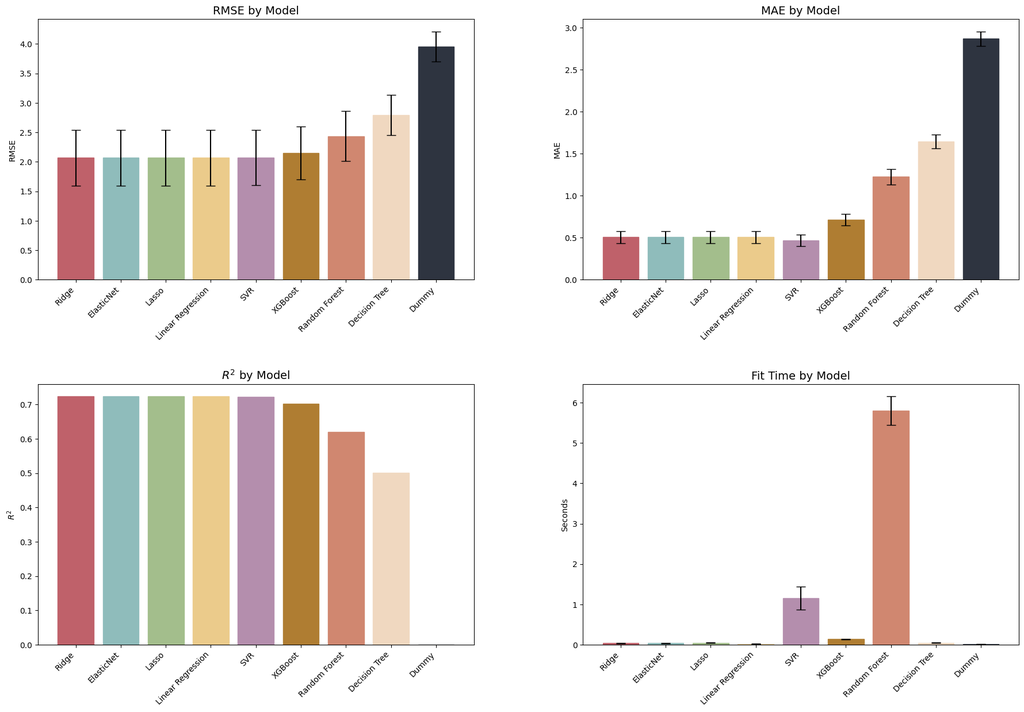

```python
plot_df = model_eval.copy()

x = np.arange(plot_df.shape[0])
labels = plot_df['Model'].tolist()


colors = fav_colors[:plot_df.shape[0]]

fig, ax = plt.subplots(nrows = 2, ncols = 2, figsize = (22, 16))
ax = ax.ravel()

# RMSE
bars = ax[0].bar(x = x,
                 height = plot_df['RMSE'],
                 yerr = plot_df['RMSE (std)'],
                 capsize = 6)

for bar, color in zip(bars, colors):
    bar.set_color(color)

ax[0].set_title('RMSE by Model', fontsize = 14)
ax[0].set_ylabel('RMSE')
ax[0].set_xticks(ticks = x, labels = labels, rotation = 45, ha = 'right')


# MAE
bars = ax[1].bar(x = x,
                 height = plot_df['MAE'],
                 yerr = plot_df['MAE (SD)'],
                 capsize = 6)

for bar, color in zip(bars, colors):
    bar.set_color(color)

ax[1].set_title('MAE by Model', fontsize = 14)
ax[1].set_ylabel('MAE')
ax[1].set_xticks(ticks = x, labels = labels, rotation = 45, ha = 'right')


# R2
bars = ax[2].bar(x = x,
                 height = plot_df['R2'])

for bar, color in zip(bars, colors):
    bar.set_color(color)

r_squared_mean = plot_df['R2'].mean()
r2_text = r'$R^2$'

ax[2].set_title(f'{r2_text} by Model', fontsize = 14)
ax[2].set_ylabel(r'$R^2$')
ax[2].set_xticks(ticks = x, labels = labels, rotation = 45, ha = 'right')
ax[2].set_ylim(bottom=0)


# Fit Time
bars = ax[3].bar(x = x,
                 height = plot_df['Fit Time'],
                 yerr = plot_df['Fit time SD'],
                 capsize = 6)

for bar, color in zip(bars, colors):
    bar.set_color(color)

ax[3].set_title('Fit Time by Model', fontsize = 14)
ax[3].set_ylabel('Seconds')
ax[3].set_xticks(ticks = x, labels = labels, rotation = 45, ha = 'right')

# Increase spacing between subplots
plt.subplots_adjust(hspace = 0.4, wspace = 0.25, bottom = 0.2)

plt.savefig(fname = FIG_DIR / 'ModelPerformanceSummary', dpi = 400)
plt.show()
plt.close()
```

Model performance was assessed using 10 fold cross-validation on the training set, with Root Mean Squared Error (RMSE) as the primary selection criterion, and Mean Absolute Error (MAE) and $R^2$ as additional metrics. RMSE was primary metric due to it penalizing larger errors more heavily, making it particularly appropriate for exam score prediction where large deviations are more consequential than small ones.

Across all linear models performance was similar. Ridge achieved the lowest RMSE (2.069), followed extremely closely by Elastic Net, Lasso, and Linear Regression, all differing only at the fourth decimal place. The $R^2$ and MAE values were nearly identical, indicating that regularization provided only marginal benefit over ordinary least squares within this dataset. This indicates that the data is well captured by a linear model.

Among nonlinear methods, SVR performed comparably to the linear models in terms of predictive accuracy, though requiring a substanially higher computational cost. XGBoost performed moderately well but did not surpass the linear models. Random Forest and Decision Tree models showed clear degradation in predictive accuracy, with higher RMSE and lower $R^2$, suggesting that additional model flexibility did not improve generalization and may have introduced excess variance. All models performed better than the Dummy regressor confirming that the predictive models meaningfully outperform a simple baseline which predicts the mean value.

In terms of computational efficiency, linear models were also the fastest to fit, while ensemble methods required significantly more training time. Given the negligible performance differences among the top linear models and their computational efficiency, Ridge regression was selected as the final model due to its slight edge in RMSE and its regularization properties that promote coefficient stability without materially increasing bias.

Overall, model evaluation demonstrates that exam performance in this dataset is primarily driven by relationships that are well approximated by linear structure, and that more complex nonlinear methods do not yield meaningful improvements in predictive accuracy.

## Final Model and Final Predictions

The Ridge model will be used to make the final predictions on the test set. The model performance will be evaluated using the previously mentioned metrics, along with a scatter plot showing predicted exam scores against observed exam scores, and a residual plot.

```python
y_pred = ridge_model.predict(X = X_test)
```

```python
from sklearn.metrics import root_mean_squared_error, mean_absolute_error, r2_score

rmse = root_mean_squared_error(y_true = y_test, y_pred = y_pred)
mae = mean_absolute_error(y_true = y_test, y_pred = y_pred)
r2 = r2_score(y_true = y_test, y_pred = y_pred)

pred_metrics = pd.DataFrame(data = {'Metrics': ['RMSE', 'MAE', 'R-squared'],
                                    'Value' : [rmse, mae, r2]})

pred_metrics['Value'] = pred_metrics['Value'].astype(float).round(3)

pred_metrics
```

|  | Metrics | Value |
| --- | --- | --- |
| 0 | RMSE | 1.852 |
| 1 | MAE | 0.479 |
| 2 | R-squared | 0.751 |

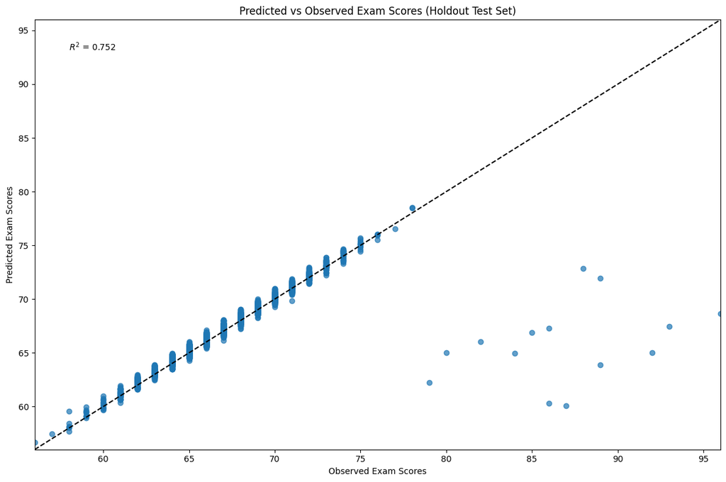

```python
from scipy.stats import linregress

slope, intercept, r_value, p_value, std_err = linregress(x = y_test, y = y_pred)

r_squared = r_value**2
r2_text = f"$R^2$ = {r_squared:.3f}"

fig, ax = plt.subplots(figsize = (12, 8))
ax.scatter(x = y_test, y = y_pred, alpha = 0.70)

min_val = min(y_test.min(), y_pred.min())
max_val = max(y_test.max(), y_pred.max())
ax.plot([min_val, max_val],
        [min_val, max_val],
        ls = '--',
        color = 'black')

ax.text(x = 0.05,
        y = 0.95,
        s = r2_text,
        transform = ax.transAxes,
        va = 'top',
        ha = 'left')

ax.set_xlabel(xlabel = 'Observed Exam Scores')
ax.set_ylabel(ylabel = 'Predicted Exam Scores')
ax.set_title(label = 'Predicted vs Observed Exam Scores (Holdout Test Set)')

ax.set_xlim(min_val, max_val)
ax.set_ylim(min_val, max_val)

plt.tight_layout()
plt.savefig(fname = FIG_DIR / 'PredictedVsObserved_ExamScore', dpi = 400)
plt.show()
plt.close()
```

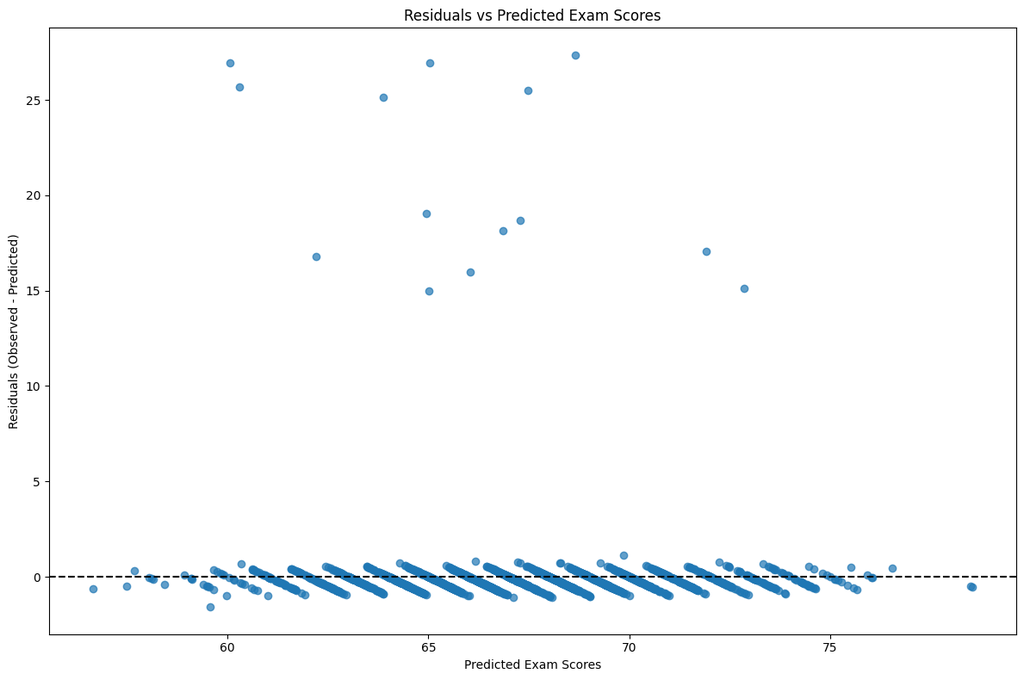

```python
resid = y_test - y_pred

fig, ax = plt.subplots(figsize = (12, 8))

ax.scatter(x = y_pred, y = resid, alpha = 0.70)

ax.axhline(y = 0,
           ls = '--',
           color = 'black')

ax.set_xlabel(xlabel = 'Predicted Exam Scores')
ax.set_ylabel(ylabel = 'Residuals (Observed - Predicted)')
ax.set_title(label = 'Residuals vs Predicted Exam Scores')

plt.tight_layout()
plt.savefig(fname = FIG_DIR / 'ResidualsVsPredicted_ExamScore', dpi = 400)
plt.show()
plt.close()
```

## Conclusions

This analysis aimed to predict `Exam_Score` using a range of regression models with structured preprocessing and 10-fold cross-validation. Across all the models evaluated, The final model chosen was Ridge Regression, as it achieved the lowest cross-validated RMSE while maintaining competitive MAE and $R^2$ values relative to the other linear approaches. However the margin of improvement over standard linear regression, lasso, and elastic net models was insignificant. The similarity in performance among the linear models suggests that the relationships between predictors and exam performance are largely linear and stable with one another. Regularization provided very minimal improvemnent indicating that collinearity was maybe mild but not severe enough to impact model performance. Tree-based models and boosting methods did not outperform any of the linear models, suggesting that nonlinear patterns or hidden interactions were not present within the data. Furthermore, the Dummy regressor performed worse compared to all models, confirming that the selected features contain meaningful predictive power simply beyond predicting the mean of exam scores.

Evaluation on the independent holdout test set confirmed that the model generalizes well, with performance metrics closely aligning with cross-validation estimates. The $R^2$ of approximately 0.75 indicates that a substantial proportion of the variability in the `Exam_Score` is explained by the selected predictors, while the relatively low RMSE and MAE suggest that prediction errors are small in magnitude relative to the outcome scale. This consistency between cross-validation and test sets indicates that overfitting was effectively managed through proper preprocessing, reguliarization and model selection procedures.